# Chapter 17 - Perceptual metaphor

Bodo Winter

8/26/2018

## Introduction

This is the analysis for Chapter 17, which is on perceptual metaphor. Here, we assume categorical sense divisions to keep things consistent with the literature on “synesthetic metaphors”. We will use this to replicate the hierarchy with a new corpus. However, we will then go further and show how the composition of the lexicon is actually a problem for the idea that there’s anything special about the hierarchy of the senses with respect to “synesthetic metaphors”.

We begin by loading in the data and libraries.

```r
## Libraries:

library(png)        # for plotting sensory modality images
library(tidyverse)
library(stringr)
library(lme4)
library(MuMIn)

## Load data:

lyn <- read_csv('../processed-data/lyn_cluster.csv')
COCA <- read_csv('../raw-data/COCA_adj_noun.csv')
strik <- read_csv('../raw-data/modality_strik_lievers_2015.csv')
war <- read_csv('../raw-data/valence_warriner_2013.csv')
snef <- read_delim('../raw-data/snefjella_kuperman_context_valence.csv',
                   delim = ' ')
SUBTL <- read_csv('../raw-data/frequency_SUBTLEX_POS.csv')
sem <- read_csv('../raw-data/lynott_connell_2009_semantic_codings.csv')
icon <- read_csv('../raw-data/iconicity_ratings.csv')

## Load plotting functions:

source('../functions/table_plotting.R')
source('../functions/chisq_NA.R')
source('../functions/predict.glmm.R')
source('../functions/emptyplot.R')
```

This time, we will use the image data (from freepix.com). So let’s load in images and specify the color values.

```r
## Load in images:

s1 <- readPNG('../figures/sight.png')
s2 <- readPNG('../figures/touch.png')
s3 <- readPNG('../figures/sound.png')
s4 <- readPNG('../figures/taste.png')
s5 <- readPNG('../figures/smell.png')

## Define vector of names:

pic_names <- str_c('s', c(2, 4, 5, 3, 1))
```

First, we need to compute the absolute valence measure for the Warriner et al. (2013) and the Snefjella and Kuperman (2016) data.

```r
## Compute absval for Warriner et al. (2013):

war <- mutate(war,
              Val_c = V.Mean.Sum - mean(V.Mean.Sum),
              Val_z = Val_c / sd(Val_c),
              AbsVal = abs(Val_z)) %>%
  select(Word, AbsVal, Val_z)

## Compute absval for Snefjella & Kuperman (2016):

snef <- mutate(snef,
               ContextVal_c = Context_Valence - mean(Context_Valence),
               ContextVal_z = ContextVal_c / sd(ContextVal_c),
               ContextAbsVal = abs(ContextVal_z)) %>%
  select(Word, ContextAbsVal, ContextVal_z)
```

## Cleaning the dataset

As was established in previous chapters, the nouns by Lynott and Connell (2009) are highly multisensory. Moreover, they have been randomly sampled. This means that the nouns often are only tangentially related to a particular sensory modality. In addition, there are very few taste and smell nouns. Because of all of these reasons, I will use theStrik Lievers (2015) dataset for nouns.

```r
strik <- filter(strik, POS == 'Noun')

## And no instruments:

strik <- filter(strik, Instrument == 'no')
```

Merge COCA with dataset with Strik Lievers (2015) noun info.

```r
COCA <- left_join(COCA, strik,
                  by = c('Noun' = 'Word'))
```

Reduce the COCA dataset to those for which there is modality information for the nouns (i.e., the nouns are represented in Strik Lievers 2015).

```r
nrow(COCA)  # 149,387
```

```
## [1] 149387
```

```r
COCA <- filter(COCA,
               !is.na(Modality))
nrow(COCA)  # 4,471
```

```
## [1] 4471
```

Check overall token frequency:

```r
sum(COCA$Freq)
```

```
## [1] 32151
```

Merge adjective modalities into strik dataset:

```r
COCA <- left_join(COCA, lyn)
```

Create a same vs. different variable for Strik:

```r
COCA <- mutate(COCA,
    Same = ifelse(Modality == DominantModality, 'yes', 'no'))
```

Add dimensionality information and get rid of dimension words:

```r
COCA$Dimension <- sem[match(COCA$Word, sem$Word), ]$Dimension

## What are dimension words, explore:

sort(filter(sem, Dimension == 'yes')$Word)
```

```
##  [1] "big"       "broad"     "bulky"     "chubby"    "colossal"
##  [6] "compact"   "deep"      "empty"     "enormous"  "fat"
## [11] "flat"      "gigantic"  "high"      "hollow"    "huge"
## [16] "immense"   "large"     "little"    "long"      "low"
## [21] "miniature" "narrow"    "open"      "petite"    "puny"
## [26] "shallow"   "sheer"     "short"     "skinny"    "small"
## [31] "steep"     "tall"      "tight"     "tiny"      "uneven"
## [36] "wide"
```

```r
length(sort(filter(sem, Dimension == 'yes')$Word))
```

```
## [1] 36
```

```r
filter(lyn, Class == 'shape & extent')$Word
```

```
##  [1] "angular"     "bent"        "bulky"       "circular"    "compact"
##  [6] "conical"     "contoured"   "creased"     "crooked"     "curly"
## [11] "curved"      "floppy"      "forked"      "hairy"       "lithe"
## [16] "little"      "long"        "loose"       "miniature"   "narrow"
## [21] "oval"        "patterned"   "petite"      "rectangular" "rotund"
## [26] "round"       "shaggy"      "sheer"       "shiny"       "short"
## [31] "skinny"      "small"       "square"      "straight"    "tall"
## [36] "tiny"        "triangular"  "wide"        "woolly"
```

```r
setdiff(filter(lyn, Class == 'shape & extent')$Word,
    sort(filter(sem, Dimension == 'yes')$Word))
```

```
##  [1] "angular"     "bent"        "circular"    "conical"     "contoured"
##  [6] "creased"     "crooked"     "curly"       "curved"      "floppy"
## [11] "forked"      "hairy"       "lithe"       "loose"       "oval"
## [16] "patterned"   "rectangular" "rotund"      "round"       "shaggy"
## [21] "shiny"       "square"      "straight"    "triangular"  "woolly"
```

Get rid of dimension words:

```r
COCA <- filter(COCA, Dimension == 'no')
nrow(COCA)  # 3,733
```

```
## [1] 3733
```

```r
sum(COCA$Freq)  # 21,679
```

```
## [1] 21679
```

Check ‘look’ and ‘eye’, which should be excluded.

```r
filter(COCA, Noun == 'look') %>% arrange(desc(Freq))
```

```
## # A tibble: 124 x 23
##    Word     Noun   Freq Modality Instrument POS   PropertyBritish
##    <chr>    <chr> <int> <chr>    <chr>      <chr> <chr>
##  1 hard     look    493 Visual   no         Noun  hard
##  2 fresh    look    182 Visual   no         Noun  fresh
##  3 strange  look    106 Visual   no         Noun  strange
##  4 sharp    look     89 Visual   no         Noun  sharp
##  5 dark     look     45 Visual   no         Noun  dark
##  6 dirty    look     43 Visual   no         Noun  dirty
##  7 sour     look     43 Visual   no         Noun  sour
##  8 polished look     38 Visual   no         Noun  polished
##  9 clean    look     29 Visual   no         Noun  clean
## 10 soft     look     22 Visual   no         Noun  soft
## # ... with 114 more rows, and 16 more variables: DominantModality <chr>,
## #   VisualStrengthMean <dbl>, HapticStrengthMean <dbl>,
## #   AuditoryStrengthMean <dbl>, GustatoryStrengthMean <dbl>,
## #   OlfactoryStrengthMean <dbl>, ModalityExclusivity <dbl>,
## #   Classes3 <int>, Uncertainty3 <dbl>, Classes <int>, Uncertainty <dbl>,
## #   Class <chr>, Color <chr>, Image <chr>, Same <chr>, Dimension <chr>
```

```r
filter(COCA, Noun == 'eye') %>% arrange(desc(Freq))
```

```
## # A tibble: 67 x 23
##    Word   Noun   Freq Modality Instrument POS   PropertyBritish
##    <chr>  <chr> <int> <chr>    <chr>      <chr> <chr>
##  1 black  eye     153 Visual   no         Noun  black
##  2 sharp  eye     148 Visual   no         Noun  sharp
##  3 red    eye      81 Visual   no         Noun  red
##  4 dry    eye      53 Visual   no         Noun  dry
##  5 green  eye      35 Visual   no         Noun  green
##  6 blue   eye      31 Visual   no         Noun  blue
##  7 smoky  eye      31 Visual   no         Noun  smoky
##  8 cold   eye      30 Visual   no         Noun  cold
##  9 yellow eye      25 Visual   no         Noun  yellow
## 10 fresh  eye      18 Visual   no         Noun  fresh
## # ... with 57 more rows, and 16 more variables: DominantModality <chr>,
## #   VisualStrengthMean <dbl>, HapticStrengthMean <dbl>,
## #   AuditoryStrengthMean <dbl>, GustatoryStrengthMean <dbl>,
## #   OlfactoryStrengthMean <dbl>, ModalityExclusivity <dbl>,
## #   Classes3 <int>, Uncertainty3 <dbl>, Classes <int>, Uncertainty <dbl>,
## #   Class <chr>, Color <chr>, Image <chr>, Same <chr>, Dimension <chr>
```

```r
COCA <- filter(COCA, !(Noun %in% c('look', 'eye')))
nrow(COCA)  # 3,542
```

```
## [1] 3542
```

```r
sum(COCA$Freq)  # 19,381
```

```
## [1] 19381
```

Take only those that are the 80% most exclusive:

```r
COCA <- filter(COCA,
    ModalityExclusivity > quantile(lyn$ModalityExclusivity, 0.20))
nrow(COCA)  # 2,571
```

```
## [1] 2571
```

```r
sum(COCA$Freq)  # 14,652
```

```
## [1] 14652
```

## Ullmann-style table with token frequencies

We will now create the first Ullmann-style table. First, we will look at token frequencies.

```r
## Summarize token frequencies:

COCA_token <- aggregate(Freq ~ Modality * DominantModality,
data = COCA, sum)

## Create an empty table:

COCA_token_tab <- matrix(numeric(25), nrow = 5)
rownames(COCA_token_tab) <- c('Haptic', 'Gustatory', 'Olfactory', 'Auditory', 'Visual')
colnames(COCA_token_tab) <- rownames(COCA_token_tab)

## Loop through the tables and add token frequencies:

for (i in 1:nrow(COCA_token_tab)) {
  for (j in 1:nrow(COCA_token_tab)) {
    this_row <- COCA_token$DominantModality == rownames(COCA_token_tab)[i]

    strik_row <- this_row & COCA_token$Modality == colnames(COCA_token_tab)[j]

    COCA_token_tab[i, j] <- COCA_token[strik_row, ]$Freq
        }
    }
```

Investigate the table:

```r
COCA_token_tab
```

```
##           Haptic Gustatory Olfactory Auditory Visual
## Haptic       288        56       275     1677    560
## Gustatory     66       734       742      288     40
## Olfactory     10        51       441        4      6
## Auditory       7         5        10     4251    108
## Visual       416        75       149     1080   3313
```

```r
sum(COCA_token_tab)
```

```
## [1] 14652
```

Next, we perform Chi-Square test, with and without the diagonal:

```r
## With diagonal:

chisq.test(COCA_token_tab)$stdres
```

```
##               Haptic  Gustatory  Olfactory  Auditory    Visual
## Haptic     12.450434 -10.613705  -2.674839  10.59704 -10.50831
## Gustatory  -3.782493  62.884788  42.322994 -31.87367 -26.28502
## Olfactory  -3.492208   3.487744  55.203474 -22.59194 -13.57567
## Auditory  -18.274312 -20.102482 -27.267888  74.64424 -44.30393
## Visual     11.240102 -17.300631 -22.566115 -49.67065  75.19775
```

```r
## Without diagonal:

COCA_token_NA <- COCA_token_tab
diag(COCA_token_NA) <- NA
chisq.test_na(COCA_token_NA)
```

```
## chisq = 3861.2, df = 11, p = 0
```

```r
stdres_fnc(COCA_token_NA)
```

```
##              Haptic  Gustatory  Olfactory   Auditory     Visual
## Haptic           NA -4.3855870 -17.238971  15.313600  18.818529
## Gustatory -4.062166         NA  41.204662 -21.848792 -10.395321
## Olfactory  1.554860 32.4042269         NA  -8.266701  -1.080715
## Auditory  -1.414559  0.3357066  -3.748719         NA  24.389840
## Visual    26.811005  2.8765075 -14.987236   8.578069         NA
```

Finally, we investigate the source / target ratios.

```r
rowSums(COCA_token_NA, na.rm = TRUE)
```

```
##    Haptic Gustatory Olfactory  Auditory    Visual
##      2568      1136        71       130      1720
```

```r
colSums(COCA_token_NA, na.rm = TRUE)
```

```
##    Haptic Gustatory Olfactory  Auditory    Visual
##       499       187      1176      3049       714
```

```r
round(rowSums(COCA_token_NA, na.rm = TRUE) /
        colSums(COCA_token_NA, na.rm = TRUE), 2)
```

```
##    Haptic Gustatory Olfactory  Auditory    Visual
##      5.15      6.07      0.06      0.04      2.41
```

## Ullmann-style table with type frequencies

We repeat the above analyses for type frequencies. In this case, each adjective-noun pair only contributes one data point, no matter how frequent or infrequent they are.

```r
## Create an empty table:

COCA_type_tab <- matrix(numeric(25), nrow = 5)
rownames(COCA_type_tab) <- c('Haptic', 'Gustatory', 'Olfactory',
                             'Auditory', 'Visual')
colnames(COCA_type_tab) <- rownames(COCA_type_tab)

## Loop through the tables and add token frequencies:

for (i in 1:nrow(COCA_type_tab)) {
    for (j in 1:nrow(COCA_type_tab)) {
            these_rows <- COCA$DominantModality == rownames(COCA_type_tab)[i]

            COCA_row <- these_rows & COCA$Modality == colnames(COCA_type_tab)[j]

            COCA_type_tab[i, j] <- sum(COCA_row)
        }
    }
```

Investigate the table:

```r
COCA_type_tab
```

```
##           Haptic Gustatory Olfactory Auditory Visual
## Haptic        56        31        52      289    152
## Gustatory     16        64        83       50     26
## Olfactory      7        15        50        4      5
## Auditory       6         3         5      575     40
## Visual        53        37        59      343    550
```

```r
sum(COCA_type_tab)
```

```
## [1] 2571
```

Next, we perform Chi-Square test, with and without the diagonal:

```r
## With diagonal:

chisq.test(COCA_type_tab)$stdres
```

```
##               Haptic  Gustatory  Olfactory    Auditory     Visual
## Haptic     5.2063850 -0.5715073 -0.6657166   0.4272911  -2.303282
## Gustatory  0.9557580 14.5045109 13.7450035  -9.1329534  -6.792360
## Olfactory  1.3286756  4.9489885 16.0927857  -8.0691525  -4.765266
## Auditory  -5.6512265 -6.5957090 -8.6741417  24.4566730 -14.919098
## Visual    -0.5222408 -4.0778401 -5.6934631 -13.5055899  20.737165
```

```r
## Without diagonal:

COCA_type_NA <- COCA_type_tab
diag(COCA_type_NA) <- NA
stdres_fnc(COCA_type_NA)
```

```
##             Haptic  Gustatory Olfactory   Auditory     Visual
## Haptic          NA -0.9797652 -4.661552  0.8318512  9.0539592
## Gustatory 1.577633         NA 12.495223 -7.1952704 -0.9822627
## Olfactory 3.713228  9.3634559        NA -4.6192009 -0.1999956
## Auditory  1.434555 -0.3546993 -1.311421         NA 11.1909917
## Visual    5.015147  0.8809639 -2.810734  9.0546916         NA
```

```r
chisq.test_na(COCA_type_NA)
```

```
## chisq = 435.1, df = 11, p = 2.13324358619612e-86
```

Finally, we investigate the source / target ratios.

```r
rowSums(COCA_type_NA, na.rm = TRUE)
```

```
##    Haptic Gustatory Olfactory  Auditory    Visual
##       524       175        31        54       492
```

```r
colSums(COCA_type_NA, na.rm = TRUE)
```

```
##    Haptic Gustatory Olfactory  Auditory    Visual
##        82        86       199       686       223
```

```r
round(rowSums(COCA_type_NA, na.rm = TRUE) /
        colSums(COCA_type_NA, na.rm = TRUE), 2)
```

```
##    Haptic Gustatory Olfactory  Auditory    Visual
##      6.39      2.03      0.16      0.08      2.21
```

## Ullmann-style table with Hapax legomena

We repeat the above analyses for hapax legomena. In this case, we only look at those adjective-noun pairs that occur just once.

```r
## Create an empty table:

COCA_hapax_tab <- matrix(numeric(25), nrow = 5)
rownames(COCA_hapax_tab) <- c('Haptic', 'Gustatory', 'Olfactory',
                              'Auditory', 'Visual')
colnames(COCA_hapax_tab) <- rownames(COCA_hapax_tab)

## Subset of those that have frequency = 1:

COCA_hapax <- filter(COCA, Freq == 1)

## Loop through the tables and add token frequencies:

for (i in 1:nrow(COCA_hapax_tab)) {
    for (j in 1:nrow(COCA_hapax_tab)) {
            these_rows <- COCA_hapax$DominantModality == rownames(COCA_hapax_tab)[i]

            COCA_row <- these_rows & COCA_hapax$Modality == colnames(COCA_hapax_tab)[j]

            COCA_hapax_tab[i, j] <- sum(COCA_row)
        }
    }
```

Investigate the table:

```r
COCA_hapax_tab
```

```
##           Haptic Gustatory Olfactory Auditory Visual
## Haptic        27        19        21      142     78
## Gustatory      8        20        31       27     19
## Olfactory      4         6        15        4      4
## Auditory       5         2         3      271     27
## Visual        29        22        31      232    270
```

```r
sum(COCA_hapax_tab)
```

```
## [1] 1317
```

Next, we perform Chi-Square test, with and without the diagonal:

```r
## With diagonal:

chisq.test(COCA_hapax_tab)$stdres
```

```
##               Haptic Gustatory Olfactory   Auditory    Visual
## Haptic     3.2355824  1.187332 -0.253313 -0.7095858 -1.269205
## Gustatory  0.9691891  6.619646  8.772889 -5.4740074 -2.820350
## Olfactory  1.6726148  3.379435  8.261368 -4.5637373 -2.293021
## Auditory  -3.4345523 -4.130220 -5.044595 14.7054267 -9.367349
## Visual    -0.8170488 -2.140059 -2.873764 -7.5195470 11.295301
```

```r
## Without diagonal:

COCA_hapax_NA <- COCA_hapax_tab
diag(COCA_hapax_NA) <- NA
stdres_fnc(COCA_hapax_NA)
```

```
##             Haptic  Gustatory  Olfactory   Auditory    Visual
## Haptic          NA  0.3558817 -2.4651149 -0.8600557 6.3644566
## Gustatory 1.187960         NA  7.3714119 -4.9480513 1.1333565
## Olfactory 2.761907  4.4991832         NA -2.9922451 0.4811644
## Auditory  1.799135 -0.3600856 -0.7555413         NA 8.9644625
## Visual    2.693396  0.1344935 -1.5799895  8.2008718        NA
```

```r
chisq.test_na(COCA_hapax_NA)
```

```
## chisq = 194.99, df = 11, p = 8.13718525885793e-36
```

Finally, we investigate the source / target ratios.

```r
rowSums(COCA_hapax_NA, na.rm = TRUE)
```

```
##    Haptic Gustatory Olfactory  Auditory    Visual
##       260        85        18        37       314
```

```r
colSums(COCA_hapax_NA, na.rm = TRUE)
```

```
##    Haptic Gustatory Olfactory  Auditory    Visual
##        46        49        86       405       128
```

```r
round(rowSums(COCA_hapax_NA, na.rm = TRUE) /
        colSums(COCA_hapax_NA, na.rm = TRUE), 2)
```

```
##    Haptic Gustatory Olfactory  Auditory    Visual
##      5.65      1.73      0.21      0.09      2.45
```

## Check within-modality cases for all tables

How many are on the diagonal, compared to how many are off the diagonal?

```r
## Counts with diagonal:

sum(diag(COCA_token_tab))
```

```
## [1] 9027
```

```r
sum(diag(COCA_type_tab))
```

```
## [1] 1295
```

```r
sum(diag(COCA_hapax_tab))
```

```
## [1] 603
```

```r
## Counts off the diagonal:

sum(COCA_token_NA, na.rm = TRUE)
```

```
## [1] 5625
```

```r
sum(COCA_type_NA, na.rm = TRUE)
```

```
## [1] 1276
```

```r
sum(COCA_hapax_NA, na.rm = TRUE)
```

```
## [1] 714
```

```r
## Proportions of within-modality cases:

sum(diag(COCA_token_tab)) / sum(COCA_token_tab)
```

```
## [1] 0.6160934
```

```r
sum(diag(COCA_type_tab)) / sum(COCA_type_tab)
```

```
## [1] 0.5036951
```

```r
sum(diag(COCA_hapax_tab)) / sum(COCA_hapax_tab)
```

```
## [1] 0.4578588
```

```r
## Check proportions of those that are OFF the diagonal:

sum(COCA_token_NA, na.rm = TRUE) /
  sum(COCA_token_tab)
```

```
## [1] 0.3839066
```

```r
sum(COCA_type_NA, na.rm = TRUE) /
  sum(COCA_type_tab)
```

```
## [1] 0.4963049
```

```r
sum(COCA_hapax_NA, na.rm = TRUE) /
  sum(COCA_hapax_tab)
```

```
## [1] 0.5421412
```

## Comparison of standardized residuals

Set labels. These will be re-used across the token, type and hapax counts.

```r
mylabs <- c('touch-to-taste', 'touch-to-smell', 'touch-to-sound',
            'touch-to-sight', 'taste-to-smell', 'taste-to-sound',
            'taste-to-sight', 'smell-to-sound', 'smell-to-sight',
            'sight-to-sound')
```

Now extract the residuals.

```r
# Extract tokens standardized residuals:

consistent <- c(stdres_fnc(COCA_token_NA)[1, 2:5],
                stdres_fnc(COCA_token_NA)[2, 3:5],
                stdres_fnc(COCA_token_NA)[3, 4:5],
                stdres_fnc(COCA_token_NA)[4, 5])
inconsistent <- c(stdres_fnc(COCA_token_NA)[2:5, 1],
                  stdres_fnc(COCA_token_NA)[3:5, 2],
                  stdres_fnc(COCA_token_NA)[4:5, 3],
                  stdres_fnc(COCA_token_NA)[5, 4])
COCA_token_STDRES <- tibble(Mapping = mylabs,
                           Consistent = consistent,
                           Inconsistent = inconsistent)

# Extract types standardized residuals:

consistent <- c(stdres_fnc(COCA_type_NA)[1, 2:5],
                stdres_fnc(COCA_type_NA)[2, 3:5],
                stdres_fnc(COCA_type_NA)[3, 4:5],
                stdres_fnc(COCA_type_NA)[4, 5])
inconsistent <- c(stdres_fnc(COCA_type_NA)[2:5, 1],
                  stdres_fnc(COCA_type_NA)[3:5, 2],
                  stdres_fnc(COCA_type_NA)[4:5, 3],
                  stdres_fnc(COCA_type_NA)[5, 4])
COCA_type_STDRES <- tibble(Mapping = mylabs,
                           Consistent = consistent,
                           Inconsistent = inconsistent)

## For hapaxes:

consistent <- c(stdres_fnc(COCA_hapax_NA)[1, 2:5],
                stdres_fnc(COCA_hapax_NA)[2, 3:5],
                stdres_fnc(COCA_hapax_NA)[3, 4:5],
                stdres_fnc(COCA_type_NA)[4, 5])
inconsistent <- c(stdres_fnc(COCA_hapax_NA)[2:5, 1],
                  stdres_fnc(COCA_hapax_NA)[3:5, 2],
                  stdres_fnc(COCA_hapax_NA)[4:5, 3],
                  stdres_fnc(COCA_hapax_NA)[5, 4])

COCA_hapax_STDRES <- tibble(Mapping = mylabs,
                            Consistent = consistent,
                            Inconsistent = inconsistent)
```

Perform descriptive comparisons. Which ones are significantly asymmetric? (using |2| as a cut-off criterion)

```r
## Tokens:

COCA_token_STDRES %>%
  mutate(Diff = round(Consistent - Inconsistent, 2))
```

```
## # A tibble: 10 x 4
##    Mapping        Consistent Inconsistent   Diff
##    <chr>               <dbl>        <dbl>  <dbl>
##  1 touch-to-taste      -4.39       -4.06   -0.32
##  2 touch-to-smell     -17.2         1.55  -18.8
##  3 touch-to-sound      15.3        -1.41   16.7
##  4 touch-to-sight      18.8        26.8    -7.99
##  5 taste-to-smell      41.2        32.4     8.8
##  6 taste-to-sound     -21.8         0.336 -22.2
##  7 taste-to-sight     -10.4         2.88  -13.3
##  8 smell-to-sound      -8.27       -3.75   -4.52
##  9 smell-to-sight      -1.08      -15.0    13.9
## 10 sight-to-sound      24.4         8.58   15.8
```

```r
## Types:

COCA_type_STDRES %>%
  mutate(Diff = round(Consistent - Inconsistent, 2))
```

```
## # A tibble: 10 x 4
##    Mapping        Consistent Inconsistent  Diff
##    <chr>               <dbl>        <dbl> <dbl>
##  1 touch-to-taste     -0.980        1.58  -2.56
##  2 touch-to-smell     -4.66         3.71  -8.37
##  3 touch-to-sound      0.832        1.43  -0.6
##  4 touch-to-sight      9.05         5.02   4.04
##  5 taste-to-smell     12.5          9.36   3.13
##  6 taste-to-sound     -7.20        -0.355 -6.84
##  7 taste-to-sight     -0.982        0.881 -1.86
##  8 smell-to-sound     -4.62        -1.31  -3.31
##  9 smell-to-sight     -0.200       -2.81   2.61
## 10 sight-to-sound     11.2          9.05   2.14
```

```r
## Hapax legomena:

COCA_hapax_STDRES %>%
  mutate(Diff = round(Consistent - Inconsistent, 2))
```

```
## # A tibble: 10 x 4
##    Mapping        Consistent Inconsistent  Diff
##    <chr>               <dbl>        <dbl> <dbl>
##  1 touch-to-taste      0.356        1.19  -0.83
##  2 touch-to-smell     -2.47         2.76  -5.23
##  3 touch-to-sound     -0.860        1.80  -2.66
##  4 touch-to-sight      6.36         2.69   3.67
##  5 taste-to-smell      7.37         4.50   2.87
##  6 taste-to-sound     -4.95        -0.360 -4.59
##  7 taste-to-sight      1.13         0.134  1
##  8 smell-to-sound     -2.99        -0.756 -2.24
##  9 smell-to-sight      0.481       -1.58   2.06
## 10 sight-to-sound     11.2          8.20   2.99
```

Perform significance tests for standardized residuals of consistent versus inconsistent mappings.

```r
## Tokens:

with(COCA_token_STDRES[-10, ],      # without sight-to-sound
     t.test(Consistent, Inconsistent, paired = TRUE))
```

```
##
##  Paired t-test
##
## data:  Consistent and Inconsistent
## t = -0.65755, df = 8, p-value = 0.5293
## alternative hypothesis: true difference in means is not equal to 0
## 95 percent confidence interval:
##  -13.845897   7.701692
## sample estimates:
## mean of the differences
##               -3.072102
```

```r
## Types:

with(COCA_type_STDRES[-10, ],       # without sight-to-sound
     t.test(Consistent, Inconsistent, paired = TRUE))
```

```
##
##  Paired t-test
##
## data:  Consistent and Inconsistent
## t = -1.0592, df = 8, p-value = 0.3204
## alternative hypothesis: true difference in means is not equal to 0
## 95 percent confidence interval:
##  -4.859328  1.800408
## sample estimates:
## mean of the differences
##                -1.52946
```

```r
## Types:

with(COCA_hapax_STDRES[-10, ],      # without sight-to-sound
     t.test(Consistent, Inconsistent, paired = TRUE))
```

```
##
##  Paired t-test
##
## data:  Consistent and Inconsistent
## t = -0.61032, df = 8, p-value = 0.5586
## alternative hypothesis: true difference in means is not equal to 0
## 95 percent confidence interval:
##  -3.153549  1.833626
## sample estimates:
## mean of the differences
##              -0.6599616
```

## Table plots:

First, we need to set some plotting parameters.

```r
## Set parameters of plot:

line_width <- 2
shen_color <- 'antiquewhite2'
```

Then we can plot the token counts.

```r
png('../figures/COCA_tokens.png', width = 850, height = 850)
par(mai = rep(1.5, 4), omi = rep(0.5, 4))
plot(1, 1, type = 'n', bty = 'n',
     xaxt = 'n', yaxt = 'n', xlab = '', ylab = '',
     xaxs = 'i', yaxs = 'i',
     xlim = c(0, 5), ylim = c(0, 5))
plot_axes(pic_names)
for (i in 0:4) {
  rect(xleft = i, xright = i + 1,
       ybottom = 4 - i, ytop = 4 + i + 1,
       col = 'lightblue')
    }
plot_shen()
plot_counts(COCA_token_tab, cex = 2.8,
            ypos = 0.5, middle = TRUE)
# plot_counts(round(stdres_fnc(COCA_token_NA), 1),
            # cex = 1.7, ypos = 0.3, stdres = TRUE)
plot_margins(COCA_token_NA,
             rect = TRUE, cex = 2.1)
plot_raster()
dev.off()
```

Next, plot of type counts:

```r
png('../figures/COCA_types.png', width = 850, height = 850)
par(mai = rep(1.5, 4), omi = rep(0.5, 4))
plot(1, 1, type = 'n', bty = 'n',
     xaxt = 'n', yaxt = 'n', xlab = '', ylab = '',
     xaxs = 'i', yaxs = 'i',
     xlim = c(0, 5), ylim = c(0, 5))
plot_axes(pic_names)
for (i in 0:4) {
    rect(xleft = i, xright = i + 1,
        ybottom = 4 - i, ytop = 4 + i + 1,
        col = 'lightblue')
    }
plot_shen()
plot_counts(COCA_type_tab, cex = 2.8,
            ypos = 0.6, middle = TRUE)
plot_counts(round(stdres_fnc(COCA_type_NA), 1),
            cex = 1.7, ypos = 0.3, stdres = TRUE)
plot_margins(COCA_type_NA, rect = TRUE, cex = 2.1)
plot_raster()
dev.off()
```

Finally, plot of hapaxes.

```r
png('../figures/COCA_hapax.png', width = 850, height = 850)
par(mai = rep(1.5, 4), omi = rep(0.5, 4))
plot(1, 1, type = 'n', bty = 'n',
     xaxt = 'n', yaxt = 'n', xlab = '', ylab = '',
     xaxs = 'i', yaxs = 'i',
     xlim = c(0, 5), ylim = c(0, 5))
plot_axes(pic_names)
for (i in 0:4) {
  rect(xleft = i, xright = i + 1,
       ybottom = 4 - i, ytop = 4 + i + 1,
       col = 'lightblue')
    }
plot_shen()
plot_counts(COCA_hapax_tab, cex = 2.8,
            ypos = 0.6, middle = TRUE)
plot_counts(round(stdres_fnc(COCA_hapax_NA), 1),
            cex = 1.7, ypos = 0.3, stdres = TRUE)
plot_margins(COCA_hapax_NA, rect = TRUE, cex = 2.1)
plot_raster()
dev.off()
```

## Assess evidence for hierarchy of the senses

We begin by defining matrices for each of the different hierarchies.

```r
ull.matches <- c(F, T, T, T, T,
    F, F, T, T, T,
    F, F, F, T, T,
    F, F, F, F, T,
    F, F, F, F, F)
shen.matches <- c(F, T, T, T, T,
    F, F, T, T, T,
    F, F, F, T, T,
    F, F, F, F, T,
    F, F, F, T, F)
will.matches <- c(F, T, F, T, T,
    F, F, T, T, F,
    F, F, F, F, F,
    F, F, F, F, T,
    F, F, F, T, F)
```

We extract the matches and mismatches:

```r
## Ullmann:

ull.matches <- matrix(ull.matches, nrow = 5, byrow = TRUE)
ull.mismatches <- !ull.matches
diag(ull.mismatches) <- FALSE

## Shen:

shen.matches <- matrix(shen.matches, nrow = 5, byrow = TRUE)
shen.mismatches <- !shen.matches
diag(shen.mismatches) <- FALSE

## Williams (1976):

will.matches <- matrix(will.matches, nrow = 5, byrow = TRUE)
will.mismatches <- !will.matches
diag(will.mismatches) <- FALSE
```

Next, we define ourselves some helper functions:

```r
## Functions that reports matches and mismatches:

hierarchy.fit <- function(xtab,
                          match = shen.matches,
                          probability = 0.5) {
  diag(xtab) <- 0

    ## Specify values to report:

    N <- sum(xtab)
    N_match <- sum(xtab[match])
    N_mismatch <- N - N_match
    percent_match <- N_match / N

    ## Values to report in character format:

    N <- str_c('N = ', N)
    N_match <- str_c('No. of matches = ',
                     N_match)
    N_mismatch <- str_c('No. of mismatches = ',
                        N_mismatch)
    percent_match <- str_c('Percent match = ',
                           round(percent_match, 2) * 100, '%')

    ## Paste this:

    cat(str_c(c(N, N_match, N_mismatch, percent_match),
              collapse = '\n'))

    }
```

Now we can use this function on our tables.

```r
## Token counts:

hierarchy.fit(COCA_token_tab, match = shen.matches)
```

```
## N = 5625
## No. of matches = 4836
## No. of mismatches = 789
## Percent match = 86%
```

```r
hierarchy.fit(COCA_token_tab, match = will.matches)
```

```
## N = 5625
## No. of matches = 4511
## No. of mismatches = 1114
## Percent match = 80%
```

```r
hierarchy.fit(COCA_token_tab, match = ull.matches)
```

```
## N = 5625
## No. of matches = 3756
## No. of mismatches = 1869
## Percent match = 67%
```

```r
## Type counts:

hierarchy.fit(COCA_type_tab, shen.matches)
```

```
## N = 1276
## No. of matches = 1075
## No. of mismatches = 201
## Percent match = 84%
```

```r
hierarchy.fit(COCA_type_tab, will.matches)
```

```
## N = 1276
## No. of matches = 988
## No. of mismatches = 288
## Percent match = 77%
```

```r
hierarchy.fit(COCA_type_tab, ull.matches)
```

```
## N = 1276
## No. of matches = 732
## No. of mismatches = 544
## Percent match = 57%
```

```r
## Hapax counts:

hierarchy.fit(COCA_hapax_tab, shen.matches)
```

```
## N = 714
## No. of matches = 604
## No. of mismatches = 110
## Percent match = 85%
```

```r
hierarchy.fit(COCA_hapax_tab, will.matches)
```

```
## N = 714
## No. of matches = 556
## No. of mismatches = 158
## Percent match = 78%
```

```r
hierarchy.fit(COCA_hapax_tab, ull.matches)
```

```
## N = 714
## No. of matches = 372
## No. of mismatches = 342
## Percent match = 52%
```

## Binomial tests of fit

Finally, we assess whether there are significantly more matches than mismatches. Importantly, the chance baseline needs to be adjusted for these binomial tests because each version of the hierarchy has a different number of cells that are allowed / disallowed.

```r
## Binomial tests tokens:

binom.test(c(sum(COCA_token_tab[shen.matches]),
             sum(COCA_token_tab[shen.mismatches])),
           p = sum(shen.matches) / 20)  # 11 out of 20 is chance
```

```
##
##  Exact binomial test
##
## data:  c(sum(COCA_token_tab[shen.matches]), sum(COCA_token_tab[shen.mismatches]))
## number of successes = 4836, number of trials = 5625, p-value <
## 2.2e-16
## alternative hypothesis: true probability of success is not equal to 0.55
## 95 percent confidence interval:
##  0.8503829 0.8687089
## sample estimates:
## probability of success
##              0.8597333
```

```r
binom.test(c(sum(COCA_token_tab[will.matches]),
             sum(COCA_token_tab[will.mismatches])),
           p = sum(will.matches) / 20)  # 7 out of 20 is chance
```

```
##
##  Exact binomial test
##
## data:  c(sum(COCA_token_tab[will.matches]), sum(COCA_token_tab[will.mismatches]))
## number of successes = 4511, number of trials = 5625, p-value <
## 2.2e-16
## alternative hypothesis: true probability of success is not equal to 0.35
## 95 percent confidence interval:
##  0.7912966 0.8123004
## sample estimates:
## probability of success
##              0.8019556
```

```r
binom.test(c(sum(COCA_token_tab[ull.matches]),
             sum(COCA_token_tab[ull.mismatches])),
           p = sum(ull.matches) / 20)   # 10 out of 20 is chance
```

```
##
##  Exact binomial test
##
## data:  c(sum(COCA_token_tab[ull.matches]), sum(COCA_token_tab[ull.mismatches]))
## number of successes = 3756, number of trials = 5625, p-value <
## 2.2e-16
## alternative hypothesis: true probability of success is not equal to 0.5
## 95 percent confidence interval:
##  0.6552506 0.6800419
## sample estimates:
## probability of success
##              0.6677333
```

```r
## Binomial tests types:

binom.test(c(sum(COCA_type_tab[shen.matches]),
             sum(COCA_type_tab[shen.mismatches])),
           p = sum(shen.matches) / 20)  # 11 out of 20 is chance
```

```
##
##  Exact binomial test
##
## data:  c(sum(COCA_type_tab[shen.matches]), sum(COCA_type_tab[shen.mismatches]))
## number of successes = 1075, number of trials = 1276, p-value <
## 2.2e-16
## alternative hypothesis: true probability of success is not equal to 0.55
## 95 percent confidence interval:
##  0.8213114 0.8620498
## sample estimates:
## probability of success
##              0.8424765
```

```r
binom.test(c(sum(COCA_type_tab[will.matches]),
             sum(COCA_type_tab[will.mismatches])),
           p = sum(will.matches) / 20)  # 7 out of 20 is chance
```

```
##
##  Exact binomial test
##
## data:  c(sum(COCA_type_tab[will.matches]), sum(COCA_type_tab[will.mismatches]))
## number of successes = 988, number of trials = 1276, p-value <
## 2.2e-16
## alternative hypothesis: true probability of success is not equal to 0.35
## 95 percent confidence interval:
##  0.7503475 0.7969710
## sample estimates:
## probability of success
##              0.7742947
```

```r
binom.test(c(sum(COCA_type_tab[ull.matches]),
             sum(COCA_type_tab[ull.mismatches])),
           p = sum(ull.matches) / 20)   # 10 out of 20 is chance
```

```
##
##  Exact binomial test
##
## data:  c(sum(COCA_type_tab[ull.matches]), sum(COCA_type_tab[ull.mismatches]))
## number of successes = 732, number of trials = 1276, p-value =
## 1.571e-07
## alternative hypothesis: true probability of success is not equal to 0.5
## 95 percent confidence interval:
##  0.5459973 0.6009980
## sample estimates:
## probability of success
##              0.5736677
```

```r
## Binomial tests hapax:

binom.test(c(sum(COCA_hapax_tab[shen.matches]),
             sum(COCA_hapax_tab[shen.mismatches])),
           p = sum(shen.matches) / 20)  # 11 out of 20 is chance
```

```
##
##  Exact binomial test
##
## data:  c(sum(COCA_hapax_tab[shen.matches]), sum(COCA_hapax_tab[shen.mismatches]))
## number of successes = 604, number of trials = 714, p-value <
## 2.2e-16
## alternative hypothesis: true probability of success is not equal to 0.55
## 95 percent confidence interval:
##  0.8173361 0.8716450
## sample estimates:
## probability of success
##              0.8459384
```

```r
binom.test(c(sum(COCA_hapax_tab[will.matches]),
             sum(COCA_hapax_tab[will.mismatches])),
           p = sum(will.matches) / 20)  # 7 out of 20 is chance
```

```
##
##  Exact binomial test
##
## data:  c(sum(COCA_hapax_tab[will.matches]), sum(COCA_hapax_tab[will.mismatches]))
## number of successes = 556, number of trials = 714, p-value <
## 2.2e-16
## alternative hypothesis: true probability of success is not equal to 0.35
## 95 percent confidence interval:
##  0.7464431 0.8086569
## sample estimates:
## probability of success
##              0.7787115
```

```r
binom.test(c(sum(COCA_hapax_tab[ull.matches]),
             sum(COCA_hapax_tab[ull.mismatches])),
           p = sum(ull.matches) / 20)   # 10 out of 20 is chance
```

```
##
##  Exact binomial test
##
## data:  c(sum(COCA_hapax_tab[ull.matches]), sum(COCA_hapax_tab[ull.mismatches]))
## number of successes = 372, number of trials = 714, p-value =
## 0.2778
## alternative hypothesis: true probability of success is not equal to 0.5
## 95 percent confidence interval:
##  0.4836433 0.5581993
## sample estimates:
## probability of success
##              0.5210084
```

## Analysis of %baseline adjectives used

How many of the adjectives from Lynott & Connell (2009) were used?

```r
mapped <- matrix(numeric(25),
                 nrow = 5)
rownames(mapped) <- c('Haptic', 'Gustatory', 'Olfactory',
                      'Auditory', 'Visual')
colnames(mapped) <- rownames(mapped)

## Need to take the exclusivity excluded lyn table for reference:

lyn_ref <- filter(lyn,
                  ModalityExclusivity > quantile(ModalityExclusivity, 0.2))

## Loop through the tables and add token frequencies:

for (i in 1:nrow(mapped)) {
    for (j in 1:nrow(mapped)) {
            this_row <- COCA$DominantModality == rownames(mapped)[i]

            COCA_row <- this_row & COCA$Modality == colnames(mapped)[j]

            these_adjs <- unique(COCA[COCA_row,]$Word)
            N_adj <- length(these_adjs)
            N_full <- nrow(lyn_ref[lyn_ref$DominantModality == rownames(mapped)[i], ])

            mapped[i, j] <- N_adj / N_full
        }
    }
round(mapped, 2)
```

```
##           Haptic Gustatory Olfactory Auditory Visual
## Haptic      0.50      0.29      0.37     0.69   0.65
## Gustatory   0.28      0.69      0.72     0.42   0.44
## Olfactory   0.39      0.44      0.72     0.22   0.28
## Auditory    0.06      0.03      0.06     0.94   0.28
## Visual      0.23      0.14      0.20     0.52   0.57
```

```r
## Look at row sums versus col sums:

mapped_NA <- mapped
diag(mapped_NA) <- NA
round(rowSums(mapped_NA, na.rm = TRUE) /
        colSums(mapped_NA, na.rm = TRUE), 2)
```

```
##    Haptic Gustatory Olfactory  Auditory    Visual
##      2.08      2.06      0.99      0.23      0.66
```

```r
## Get average percentage based on hierarchy:

mean(mapped[shen.matches])
```

```
## [1] 0.4437468
```

```r
mean(mapped[shen.mismatches])
```

```
## [1] 0.2037577
```

```r
wilcox.test(mapped[shen.matches],
            mapped[shen.mismatches], paired = FALSE)
```

```
##
##  Wilcoxon rank sum test with continuity correction
##
## data:  mapped[shen.matches] and mapped[shen.mismatches]
## W = 84, p-value = 0.009709
## alternative hypothesis: true location shift is not equal to 0
```

```r
mean(mapped[ull.matches])
```

```
## [1] 0.4360256
```

```r
mean(mapped[ull.mismatches])
```

```
## [1] 0.2354778
```

```r
mean(mapped[will.matches])
```

```
## [1] 0.5101979
```

```r
mean(mapped[will.mismatches])
```

```
## [1] 0.2418191
```

```r
## Plot this:

png('../figures/COCA_baseline.png', width = 850, height = 850)
par(mai = rep(1.5, 4), omi = rep(0.5, 4))
plot(1, 1, type = 'n', bty = 'n',
    xaxt = 'n', yaxt = 'n', xlab = '', ylab = '',
    xaxs = 'i', yaxs = 'i',
    xlim = c(0, 5), ylim = c(0, 5))
plot_axes(pic_names)
for (i in 0:4) {
    rect(xleft = i, xright = i + 1,
        ybottom = 4 - i, ytop = 4 + i + 1,
        col = 'lightblue')
    }
plot_shen()
plot_percent(round(mapped, 2) * 100,
             cex = 2.3, ypos = 0.5)
plot_margins(round(mapped, 2) * 100,
             rect = TRUE, percent = TRUE)
plot_raster()
dev.off()
```

## Model comparison of hierarchies

We can make the data into long format and use generalized linear models to look at which hierarchy predicts the counts best.

```r
## Define vectors of names to loop through:

mytabs <- c('COCA_token_NA', 'COCA_type_NA', 'COCA_hapax_NA')

## Define vectors of names of datasets to put into:

mylongs <- c('COCA_token_long', 'COCA_type_long', 'COCA_hapax_long')

## Loop through and make long:

for (k in seq_along(mytabs)) {
    x <- get(mytabs[k])
    xdf <- c()
    for (i in 1:5) {
        for (j in 1:5) {
            this_df <- data.frame(Mapping = str_c(row.names(x)[i],
                                                  '-', row.names(x)[j]),
                                  Count = x[i, j])
            xdf <- rbind(xdf, this_df)
            }
        }
    xdf$Shen <- c(NA, 'yes', 'yes', 'yes', 'yes', 'no',
        NA, 'yes', 'yes', 'yes', 'no', 'no',
        NA, 'yes', 'yes', 'no', 'no', 'no',
        NA, 'yes', 'no', 'no', 'no', 'yes',
        NA)
    xdf$Ull <- c(NA, 'yes', 'yes', 'yes', 'yes', 'no',
        NA, 'yes', 'yes', 'yes', 'no', 'no',
        NA, 'yes', 'yes', 'no', 'no', 'no',
        NA, 'yes', 'no', 'no', 'no', 'no',
        NA)
    xdf$Will <- c(NA, 'yes', 'no', 'yes', 'yes', 'no',
        NA, 'yes', 'no', 'no', 'no', 'no',
        NA, 'no', 'no', 'no', 'no', 'no',
        NA, 'yes', 'no', 'no', 'no', 'no',
        NA)

    assign(mylongs[k], na.omit(xdf))
    }

## Make Poisson models of this, starting with token models:

summary(glm(Count ~ Shen,
            data = COCA_token_long, family = 'poisson'))
```

```
##
## Call:
## glm(formula = Count ~ Shen, family = "poisson", data = COCA_token_long)
##
## Deviance Residuals:
##     Min       1Q   Median       3Q      Max
## -28.873  -13.512   -8.081    5.616   44.896
##
## Coefficients:
##             Estimate Std. Error z value Pr(>|z|)
## (Intercept)   4.4735     0.0356  125.66   <2e-16 ***
## Shenyes       1.6124     0.0384   41.99   <2e-16 ***
## ---
## Signif. codes:  0 '***' 0.001 '**' 0.01 '*' 0.05 '.' 0.1 ' ' 1
##
## (Dispersion parameter for poisson family taken to be 1)
##
##     Null deviance: 9830.5  on 19  degrees of freedom
## Residual deviance: 7349.5  on 18  degrees of freedom
## AIC: 7476.3
##
## Number of Fisher Scoring iterations: 6
```

```r
summary(glm(Count ~ Ull,
            data = COCA_token_long, family = 'poisson'))
```

```
##
## Call:
## glm(formula = Count ~ Ull, family = "poisson", data = COCA_token_long)
##
## Deviance Residuals:
##     Min       1Q   Median       3Q      Max
## -26.587  -17.811  -11.011    0.059   49.149
##
## Coefficients:
##             Estimate Std. Error z value Pr(>|z|)
## (Intercept)  5.23057    0.02313  226.13   <2e-16 ***
## Ullyes       0.69795    0.02831   24.66   <2e-16 ***
## ---
## Signif. codes:  0 '***' 0.001 '**' 0.01 '*' 0.05 '.' 0.1 ' ' 1
##
## (Dispersion parameter for poisson family taken to be 1)
##
##     Null deviance: 9830.5  on 19  degrees of freedom
## Residual deviance: 9185.1  on 18  degrees of freedom
## AIC: 9311.8
##
## Number of Fisher Scoring iterations: 6
```

```r
summary(glm(Count ~ Will,
            data = COCA_token_long, family = 'poisson'))
```

```
##
## Call:
## glm(formula = Count ~ Will, family = "poisson", data = COCA_token_long)
##
## Deviance Residuals:
##     Min       1Q   Median       3Q      Max
## -29.570  -16.561   -9.622    5.239   47.148
##
## Coefficients:
##             Estimate Std. Error z value Pr(>|z|)
## (Intercept)  5.10877    0.02007   254.5   <2e-16 ***
## Willyes      1.33473    0.02685    49.7   <2e-16 ***
## ---
## Signif. codes:  0 '***' 0.001 '**' 0.01 '*' 0.05 '.' 0.1 ' ' 1
##
## (Dispersion parameter for poisson family taken to be 1)
##
##     Null deviance: 9830.5  on 19  degrees of freedom
## Residual deviance: 7408.3  on 18  degrees of freedom
## AIC: 7535.1
##
## Number of Fisher Scoring iterations: 6
```

```r
## Type models:

summary(glm(Count ~ Shen,
            data = COCA_type_long, family = 'poisson'))
```

```
##
## Call:
## glm(formula = Count ~ Shen, family = "poisson", data = COCA_type_long)
##
## Deviance Residuals:
##     Min       1Q   Median       3Q      Max
## -12.723   -5.658   -3.954    3.393   19.255
##
## Coefficients:
##             Estimate Std. Error z value Pr(>|z|)
## (Intercept)  3.10608    0.07053   44.04   <2e-16 ***
## Shenyes      1.47610    0.07685   19.21   <2e-16 ***
## ---
## Signif. codes:  0 '***' 0.001 '**' 0.01 '*' 0.05 '.' 0.1 ' ' 1
##
## (Dispersion parameter for poisson family taken to be 1)
##
##     Null deviance: 1852.5  on 19  degrees of freedom
## Residual deviance: 1357.7  on 18  degrees of freedom
## AIC: 1464.5
##
## Number of Fisher Scoring iterations: 5
```

```r
summary(glm(Count ~ Ull,
            data = COCA_type_long, family = 'poisson'))
```

```
##
## Call:
## glm(formula = Count ~ Ull, family = "poisson", data = COCA_type_long)
##
## Deviance Residuals:
##      Min        1Q    Median        3Q       Max
## -10.7306   -8.1941   -4.9142    0.0108   26.1912
##
## Coefficients:
##             Estimate Std. Error z value Pr(>|z|)
## (Intercept)  3.99636    0.04287  93.210  < 2e-16 ***
## Ullyes       0.29683    0.05661   5.244 1.57e-07 ***
## ---
## Signif. codes:  0 '***' 0.001 '**' 0.01 '*' 0.05 '.' 0.1 ' ' 1
##
## (Dispersion parameter for poisson family taken to be 1)
##
##     Null deviance: 1852.5  on 19  degrees of freedom
## Residual deviance: 1824.7  on 18  degrees of freedom
## AIC: 1931.5
##
## Number of Fisher Scoring iterations: 6
```

```r
summary(glm(Count ~ Will,
            data = COCA_type_long, family = 'poisson'))
```

```
##
## Call:
## glm(formula = Count ~ Will, family = "poisson", data = COCA_type_long)
##
## Deviance Residuals:
##     Min       1Q   Median       3Q      Max
## -9.6230  -7.6642  -4.2672   0.9925  28.1432
##
## Coefficients:
##             Estimate Std. Error z value Pr(>|z|)
## (Intercept)  3.81551    0.03832   99.57   <2e-16 ***
## Willyes      0.96361    0.05612   17.17   <2e-16 ***
## ---
## Signif. codes:  0 '***' 0.001 '**' 0.01 '*' 0.05 '.' 0.1 ' ' 1
##
## (Dispersion parameter for poisson family taken to be 1)
##
##     Null deviance: 1852.5  on 19  degrees of freedom
## Residual deviance: 1574.1  on 18  degrees of freedom
## AIC: 1680.9
##
## Number of Fisher Scoring iterations: 6
```

```r
## Hapax models:

summary(glm(Count ~ Shen,
            data = COCA_hapax_long, family = 'poisson'))
```

```
##
## Call:
## glm(formula = Count ~ Shen, family = "poisson", data = COCA_hapax_long)
##
## Deviance Residuals:
##    Min      1Q  Median      3Q     Max
## -8.992  -4.446  -2.953   2.616  17.733
##
## Coefficients:
##             Estimate Std. Error z value Pr(>|z|)
## (Intercept)  2.50326    0.09535   26.25   <2e-16 ***
## Shenyes      1.50242    0.10367   14.49   <2e-16 ***
## ---
## Signif. codes:  0 '***' 0.001 '**' 0.01 '*' 0.05 '.' 0.1 ' ' 1
##
## (Dispersion parameter for poisson family taken to be 1)
##
##     Null deviance: 1087.30  on 19  degrees of freedom
## Residual deviance:  803.03  on 18  degrees of freedom
## AIC: 899.24
##
## Number of Fisher Scoring iterations: 5
```

```r
summary(glm(Count ~ Ull,
            data = COCA_hapax_long, family = 'poisson'))
```

```
##
## Call:
## glm(formula = Count ~ Ull, family = "poisson", data = COCA_hapax_long)
##
## Deviance Residuals:
##    Min      1Q  Median      3Q     Max
## -7.283  -6.338  -3.096  -1.014  22.198
##
## Coefficients:
##             Estimate Std. Error z value Pr(>|z|)
## (Intercept)  3.53223    0.05407  65.322   <2e-16 ***
## Ullyes       0.08408    0.07491   1.122    0.262
## ---
## Signif. codes:  0 '***' 0.001 '**' 0.01 '*' 0.05 '.' 0.1 ' ' 1
##
## (Dispersion parameter for poisson family taken to be 1)
##
##     Null deviance: 1087.3  on 19  degrees of freedom
## Residual deviance: 1086.0  on 18  degrees of freedom
## AIC: 1182.2
##
## Number of Fisher Scoring iterations: 6
```

```r
summary(glm(Count ~ Will,
            data = COCA_hapax_long, family = 'poisson'))
```

```
##
## Call:
## glm(formula = Count ~ Will, family = "poisson", data = COCA_hapax_long)
##
## Deviance Residuals:
##     Min       1Q   Median       3Q      Max
## -6.4088  -5.6648  -4.2474  -0.0579  24.0014
##
## Coefficients:
##             Estimate Std. Error z value Pr(>|z|)
## (Intercept)  3.32504    0.04897    67.9   <2e-16 ***
## Willyes      0.75926    0.07593    10.0   <2e-16 ***
## ---
## Signif. codes:  0 '***' 0.001 '**' 0.01 '*' 0.05 '.' 0.1 ' ' 1
##
## (Dispersion parameter for poisson family taken to be 1)
##
##     Null deviance: 1087.30  on 19  degrees of freedom
## Residual deviance:  993.46  on 18  degrees of freedom
## AIC: 1089.7
##
## Number of Fisher Scoring iterations: 6
```

```r
## Token BIC:

BIC(glm(Count ~ Shen,
        data = COCA_token_long, family = 'poisson'))
```

```
## [1] 7478.25
```

```r
BIC(glm(Count ~ Ull,
        data = COCA_token_long, family = 'poisson'))
```

```
## [1] 9313.825
```

```r
BIC(glm(Count ~ Will,
        data = COCA_token_long, family = 'poisson'))
```

```
## [1] 7537.044
```

```r
## Type BIC:

BIC(glm(Count ~ Shen,
        data = COCA_type_long, family = 'poisson'))
```

```
## [1] 1466.484
```

```r
BIC(glm(Count ~ Ull,
        data = COCA_type_long, family = 'poisson'))
```

```
## [1] 1933.535
```

```r
BIC(glm(Count ~ Will,
        data = COCA_type_long, family = 'poisson'))
```

```
## [1] 1682.933
```

```r
## Hapax BIC:

BIC(glm(Count ~ Shen,
        data = COCA_hapax_long, family = 'poisson'))
```

```
## [1] 901.2357
```

```r
BIC(glm(Count ~ Ull,
        data = COCA_hapax_long, family = 'poisson'))
```

```
## [1] 1184.236
```

```r
BIC(glm(Count ~ Will,
        data = COCA_hapax_long, family = 'poisson'))
```

```
## [1] 1091.661
```

## What’s the baseline?

We can create a “baseline” by looking at all the possible combinations of Lynott and Connell (2009).

First, the setup:

```r
## Take unique adjectives of Lynott & Connell (2009) and combine with Strik Lievers (2015):

allc <- as_tibble(expand.grid(lyn$Word, strik$Word))

## Merge with modality info:

allc <- allc %>%
  rename(Word = Var1,
         Noun = Var2) %>%
  left_join(dplyr::select(lyn, Word, DominantModality))
allc <- allc %>%
  left_join(strik,
            by = c('Noun' = 'Word'))
## Rename for ease:

allc <- rename(allc,
               NounMod = Modality,
               Mod = DominantModality)
```

We will now check how many of those “all combinations” fit the hierarchy, using only Shen’s version of the hierarchy here.

```r
## Check consistent cases:

allc$MatchShen <- 'no'
allc[allc$Mod == allc$NounMod, ]$MatchShen <- NA
matches <- allc$Mod == 'Haptic' & allc$NounMod == 'Gustatory'
matches <- matches |
  (allc$Mod == 'Haptic' & allc$NounMod == 'Olfactory')
matches <- matches |
  (allc$Mod == 'Haptic' & allc$NounMod == 'Auditory')
matches <- matches |
  (allc$Mod == 'Haptic' & allc$NounMod == 'Visual')
matches <- matches |
  (allc$Mod == 'Gustatory' & allc$NounMod == 'Olfactory')
matches <- matches |
  (allc$Mod == 'Gustatory' & allc$NounMod == 'Auditory')
matches <- matches |
  (allc$Mod == 'Gustatory' & allc$NounMod == 'Visual')
matches <- matches |
  (allc$Mod == 'Olfactory' & allc$NounMod == 'Auditory')
matches <- matches |
  (allc$Mod == 'Olfactory' & allc$NounMod == 'Visual')
matches <- matches | (allc$Mod == 'Auditory' & allc$NounMod == 'Visual')
matches <- matches |
  (allc$Mod == 'Visual' & allc$NounMod == 'Auditory')
allc[matches, ]$MatchShen <- 'yes'

## Calculate:

table(allc$MatchShen)
```

```
##
##    no   yes
## 11105 51507
```

```r
prop.table(table(allc$MatchShen))
```

```
##
##        no       yes
## 0.1773622 0.8226378
```

```r
## Binomial test of this:

binom.test(rev(table(allc$MatchShen)),
           p = sum(shen.matches) / 20)
```

```
##
##  Exact binomial test
##
## data:  rev(table(allc$MatchShen))
## number of successes = 51507, number of trials = 62612, p-value <
## 2.2e-16
## alternative hypothesis: true probability of success is not equal to 0.55
## 95 percent confidence interval:
##  0.8196230 0.8256228
## sample estimates:
## probability of success
##              0.8226378
```

```r
nrow(na.omit(allc))
```

```
## [1] 62612
```

```r
nrow(na.omit(allc)) / nrow(allc)
```

```
## [1] 0.7669374
```

```r
## Crosstabulate:

xtab <- table(allc$Mod, allc$NounMod)
diag(xtab) <- NA

## Source and target sums:

rowSums(xtab, na.rm = TRUE)
```

```
##  Auditory Gustatory    Haptic Olfactory    Visual
##      5848      9666     12950      4628     29520
```

```r
colSums(xtab, na.rm = TRUE)
```

```
##  Auditory Gustatory    Haptic Olfactory    Visual
##     37985      5166      2824      5955     10682
```

```r
## Source-target ratios:

rowSums(xtab, na.rm = TRUE) /
  colSums(xtab, na.rm = TRUE)
```

```
##  Auditory Gustatory    Haptic Olfactory    Visual
## 0.1539555 1.8710801 4.5856941 0.7771620 2.7635274
```

```r
round(rowSums(xtab, na.rm = TRUE) /
        colSums(xtab, na.rm = TRUE), 2)
```

```
##  Auditory Gustatory    Haptic Olfactory    Visual
##      0.15      1.87      4.59      0.78      2.76
```

## Influence of valence and iconicity

Merge valence and iconicity in there:

```r
COCA <- left_join(COCA, war,
                  by = c('Word' = 'Word'))
COCA <- left_join(COCA, snef,
                  by = c('Word' = 'Word'))
COCA <- left_join(COCA, icon,
                  by = c('Word' = 'Word'))
```

Fit a logistic regression of same/different as a function of absolute valence:

```r
## Code factor so that we model change towards "different":

COCA <- mutate(COCA,
               Same = factor(Same, level = c('yes', 'no')))

## Valence and context valence:

summary(absval.mdl <- glmer(Same ~ AbsVal +
                              (1|Word) +
                              (1 + AbsVal|Noun),
                            data = COCA, family = 'binomial'))
```

```
## Generalized linear mixed model fit by maximum likelihood (Laplace
##   Approximation) [glmerMod]
##  Family: binomial  ( logit )
## Formula: Same ~ AbsVal + (1 | Word) + (1 + AbsVal | Noun)
##    Data: COCA
##
##      AIC      BIC   logLik deviance df.resid
##   1812.9   1846.3   -900.5   1800.9     1932
##
## Scaled residuals:
##     Min      1Q  Median      3Q     Max
## -7.5878 -0.4391  0.1364  0.4143 11.3694
##
## Random effects:
##  Groups Name        Variance Std.Dev. Corr
##  Word   (Intercept) 3.823    1.955
##  Noun   (Intercept) 1.552    1.246
##         AbsVal      0.131    0.362    1.00
## Number of obs: 1938, groups:  Word, 148; Noun, 144
##
## Fixed effects:
##             Estimate Std. Error z value Pr(>|z|)
## (Intercept)  -0.3089     0.3698  -0.835   0.4035
## AbsVal        0.7191     0.3197   2.250   0.0245 *
## ---
## Signif. codes:  0 '***' 0.001 '**' 0.01 '*' 0.05 '.' 0.1 ' ' 1
##
## Correlation of Fixed Effects:
##        (Intr)
## AbsVal -0.754
```

```r
summary(absval_context.mdl <- glmer(Same ~ ContextAbsVal +
                                      (1|Word) +
                                      (1 + ContextAbsVal|Noun),
                                    data = COCA, family = 'binomial'))
```

```
## Generalized linear mixed model fit by maximum likelihood (Laplace
##   Approximation) [glmerMod]
##  Family: binomial  ( logit )
## Formula: Same ~ ContextAbsVal + (1 | Word) + (1 + ContextAbsVal | Noun)
##    Data: COCA
##
##      AIC      BIC   logLik deviance df.resid
##   2478.2   2513.3  -1233.1   2466.2     2557
##
## Scaled residuals:
##     Min      1Q  Median      3Q     Max
## -6.4652 -0.4309 -0.1158  0.4250 12.7827
##
## Random effects:
##  Groups Name          Variance Std.Dev. Corr
##  Word   (Intercept)   5.1210   2.2630
##  Noun   (Intercept)   2.1667   1.4720
##         ContextAbsVal 0.4285   0.6546   -0.20
## Number of obs: 2563, groups:  Word, 259; Noun, 146
##
## Fixed effects:
##               Estimate Std. Error z value Pr(>|z|)
## (Intercept)    -0.2855     0.3059  -0.933    0.351
## ContextAbsVal  -0.2582     0.3321  -0.777    0.437
##
## Correlation of Fixed Effects:
##             (Intr)
## ContxtAbsVl -0.701
```

```r
summary(icon.mdl <- glmer(Same ~ Iconicity +
                            (1|Word) +
                            (1 + Iconicity|Noun),
                          data = COCA, family = 'binomial',
                          control = glmerControl(optimizer = 'bobyqa')))
```

```
## Generalized linear mixed model fit by maximum likelihood (Laplace
##   Approximation) [glmerMod]
##  Family: binomial  ( logit )
## Formula: Same ~ Iconicity + (1 | Word) + (1 + Iconicity | Noun)
##    Data: COCA
## Control: glmerControl(optimizer = "bobyqa")
##
##      AIC      BIC   logLik deviance df.resid
##   2473.3   2508.4  -1230.7   2461.3     2565
##
## Scaled residuals:
##     Min      1Q  Median      3Q     Max
## -5.7215 -0.4246 -0.1164  0.4227 10.9374
##
## Random effects:
##  Groups Name        Variance Std.Dev. Corr
##  Word   (Intercept) 4.9140   2.2168
##  Noun   (Intercept) 2.6772   1.6362
##         Iconicity   0.1061   0.3257   -0.53
## Number of obs: 2571, groups:  Word, 262; Noun, 146
##
## Fixed effects:
##             Estimate Std. Error z value Pr(>|z|)
## (Intercept)   0.3102     0.3163   0.981 0.326729
## Iconicity    -0.5036     0.1528  -3.295 0.000985 ***
## ---
## Signif. codes:  0 '***' 0.001 '**' 0.01 '*' 0.05 '.' 0.1 ' ' 1
##
## Correlation of Fixed Effects:
##           (Intr)
## Iconicity -0.732
```

The emotional valence and iconicity effects may be driven by gustatory/olfactory strength and auditory strength … thus, they may actually be modality-specific effects in disguise. It is thus useful to consider the respective perceptual strength measures as covariates, to assess the extent to which the two linguistic factors survive if those are controlled for.

```r
## Valence and context valence:

summary(absval_gus.mdl <- glmer(Same ~ AbsVal +
                                  GustatoryStrengthMean +
                                  OlfactoryStrengthMean +
                              (1|Word) +
                              (1 + AbsVal|Noun),
                            data = COCA, family = 'binomial'))
```

```
## Generalized linear mixed model fit by maximum likelihood (Laplace
##   Approximation) [glmerMod]
##  Family: binomial  ( logit )
## Formula: Same ~ AbsVal + GustatoryStrengthMean + OlfactoryStrengthMean +
##     (1 | Word) + (1 + AbsVal | Noun)
##    Data: COCA
##
##      AIC      BIC   logLik deviance df.resid
##   1793.7   1838.2   -888.8   1777.7     1930
##
## Scaled residuals:
##     Min      1Q  Median      3Q     Max
## -7.9093 -0.4335  0.1336  0.4177 10.7869
##
## Random effects:
##  Groups Name        Variance Std.Dev. Corr
##  Word   (Intercept) 2.9846   1.7276
##  Noun   (Intercept) 1.4451   1.2021
##         AbsVal      0.1639   0.4049   1.00
## Number of obs: 1938, groups:  Word, 148; Noun, 144
##
## Fixed effects:
##                       Estimate Std. Error z value Pr(>|z|)
## (Intercept)            -0.8683     0.3616  -2.401 0.016332 *
## AbsVal                  1.0520     0.3174   3.314 0.000920 ***
## GustatoryStrengthMean   0.8481     0.1683   5.041 4.64e-07 ***
## OlfactoryStrengthMean  -0.6609     0.1823  -3.625 0.000289 ***
## ---
## Signif. codes:  0 '***' 0.001 '**' 0.01 '*' 0.05 '.' 0.1 ' ' 1
##
## Correlation of Fixed Effects:
##             (Intr) AbsVal GsttSM
## AbsVal      -0.676
## GsttryStrnM -0.325  0.231
## OlfctryStrM  0.135 -0.378 -0.690
```

```r
COCA <- mutate(COCA,
               gus_c = GustatoryStrengthMean - mean(GustatoryStrengthMean),
               olf_c = OlfactoryStrengthMean -
                 mean(OlfactoryStrengthMean),
               absval_c = ContextAbsVal -
                 mean(ContextAbsVal, na.rm = TRUE))
summary(absval_context_gus.mdl <- glmer(Same ~ absval_c +
                                      olf_c +
                                      gus_c +
                                      (1|Word) +
                                      (1 + absval_c|Noun),
                                    data = COCA, family = 'binomial'))
```

```
## Generalized linear mixed model fit by maximum likelihood (Laplace
##   Approximation) [glmerMod]
##  Family: binomial  ( logit )
## Formula: Same ~ absval_c + olf_c + gus_c + (1 | Word) + (1 + absval_c |
##     Noun)
##    Data: COCA
##
##      AIC      BIC   logLik deviance df.resid
##   2443.5   2490.3  -1213.8   2427.5     2555
##
## Scaled residuals:
##     Min      1Q  Median      3Q     Max
## -6.3310 -0.4219 -0.1153  0.4232 12.2293
##
## Random effects:
##  Groups Name        Variance Std.Dev. Corr
##  Word   (Intercept) 4.1631   2.0404
##  Noun   (Intercept) 2.0659   1.4373
##         absval_c    0.5226   0.7229   0.10
## Number of obs: 2563, groups:  Word, 259; Noun, 146
##
## Fixed effects:
##               Estimate Std. Error z value Pr(>|z|)
## (Intercept) -0.3659024  0.0004940  -740.7   <2e-16 ***
## absval_c    -0.5978954  0.0004940 -1210.4   <2e-16 ***
## olf_c       -0.2048518  0.0004941  -414.6   <2e-16 ***
## gus_c        0.8220171  0.0004942  1663.3   <2e-16 ***
## ---
## Signif. codes:  0 '***' 0.001 '**' 0.01 '*' 0.05 '.' 0.1 ' ' 1
##
## Correlation of Fixed Effects:
##          (Intr) absvl_ olf_c
## absval_c 0.000
## olf_c    0.000  0.000
## gus_c    0.000  0.000  0.000
## convergence code: 0
## Model failed to converge with max|grad| = 0.143255 (tol = 0.001, component 1)
## Model is nearly unidentifiable: very large eigenvalue
##  - Rescale variables?
```

```r
summary(icon_aud.mdl <- glmer(Same ~ Iconicity +
                                AuditoryStrengthMean +
                                (1|Word) +
                                (1 + Iconicity|Noun),
                          data = COCA, family = 'binomial'))
```

```
## Generalized linear mixed model fit by maximum likelihood (Laplace
##   Approximation) [glmerMod]
##  Family: binomial  ( logit )
## Formula:
## Same ~ Iconicity + AuditoryStrengthMean + (1 | Word) + (1 + Iconicity |
##     Noun)
##    Data: COCA
##
##      AIC      BIC   logLik deviance df.resid
##   2356.1   2397.0  -1171.0   2342.1     2564
##
## Scaled residuals:
##     Min      1Q  Median      3Q     Max
## -5.0063 -0.4248 -0.0951  0.4045 13.4924
##
## Random effects:
##  Groups Name        Variance Std.Dev. Corr
##  Word   (Intercept) 2.5973   1.6116
##  Noun   (Intercept) 2.9609   1.7207
##         Iconicity   0.1219   0.3491   -0.48
## Number of obs: 2571, groups:  Word, 262; Noun, 146
##
## Fixed effects:
##                      Estimate Std. Error z value Pr(>|z|)
## (Intercept)           1.15208    0.29606   3.891 9.97e-05 ***
## Iconicity             0.02420    0.13447   0.180    0.857
## AuditoryStrengthMean -0.98786    0.09132 -10.818  < 2e-16 ***
## ---
## Signif. codes:  0 '***' 0.001 '**' 0.01 '*' 0.05 '.' 0.1 ' ' 1
##
## Correlation of Fixed Effects:
##             (Intr) Icncty
## Iconicity   -0.572
## AdtryStrngM -0.305 -0.231
```

Absolute valence has a strong positive effect, even if controlling for gustatory and olfactory strength (which are higher in valence). This model also has no convergence issues.

There is a weird and unpredicted negative relationship with context valence in a model that also has convergence issues.

```r
sound <- filter(COCA, DominantModality == 'Auditory')
summary(icon_subset.mdl <- glmer(Same ~ Iconicity +
                                (1|Word) +
                                (1 + Iconicity|Noun),
                          data = sound, family = 'binomial',
                          control = glmerControl(optimizer = 'bobyqa')))
```

```
## Generalized linear mixed model fit by maximum likelihood (Laplace
##   Approximation) [glmerMod]
##  Family: binomial  ( logit )
## Formula: Same ~ Iconicity + (1 | Word) + (1 + Iconicity | Noun)
##    Data: sound
## Control: glmerControl(optimizer = "bobyqa")
##
##      AIC      BIC   logLik deviance df.resid
##     97.2    123.9    -42.6     85.2      623
##
## Scaled residuals:
##       Min        1Q    Median        3Q       Max
## -0.006587 -0.001294 -0.000978 -0.000486  0.133960
##
## Random effects:
##  Groups Name        Variance  Std.Dev. Corr
##  Noun   (Intercept) 1.542e+03 39.26
##         Iconicity   2.611e+01  5.11    1.00
##  Word   (Intercept) 3.998e-02  0.20
## Number of obs: 629, groups:  Noun, 106; Word, 61
##
## Fixed effects:
##               Estimate Std. Error z value Pr(>|z|)
## (Intercept) -12.122872   0.002438 -4972.1   <2e-16 ***
## Iconicity    -0.971627   0.002441  -398.1   <2e-16 ***
## ---
## Signif. codes:  0 '***' 0.001 '**' 0.01 '*' 0.05 '.' 0.1 ' ' 1
##
## Correlation of Fixed Effects:
##           (Intr)
## Iconicity 0.000
## convergence code: 0
## Model failed to converge with max|grad| = 0.0291184 (tol = 0.001, component 1)
```

(There are convergence issues for this model as well, but it’s still comforting to know that the pattern works within sound as well.)

Odds ratios for reporting:

```r
exp(fixef(absval.mdl)['AbsVal'])
```

```
##   AbsVal
## 2.052518
```

```r
exp(fixef(absval_context.mdl)['ContextAbsVal'])
```

```
## ContextAbsVal
##     0.7724749
```

```r
exp(fixef(icon.mdl)['Iconicity'])
```

```
## Iconicity
## 0.6043781
```

Get predictions for the two models with significant terms (absolute valence and iconicity). First, we define the predictor space:

```r
## Check range:

range(COCA$AbsVal, na.rm = TRUE)
```

```
## [1] 0.01086126 2.38753400
```

```r
range(COCA$Iconicity, na.rm = TRUE)
```

```
## [1] -2.166667  4.461538
```

```r
## Define predictors:

AbsVal <- seq(-1, 3, 0.01)
Iconicity <- seq(-3, 6, 0.01)
```

Extract the predictions from the model:

```r
absval_pred <- predict.glmm(fit = absval.mdl,
             newdata = tibble(AbsVal),
             type = 'binomial')
icon_pred <- predict.glmm(fit = icon.mdl,
             newdata = tibble(Iconicity),
             type = 'binomial')
```

Make a double-plot of this.

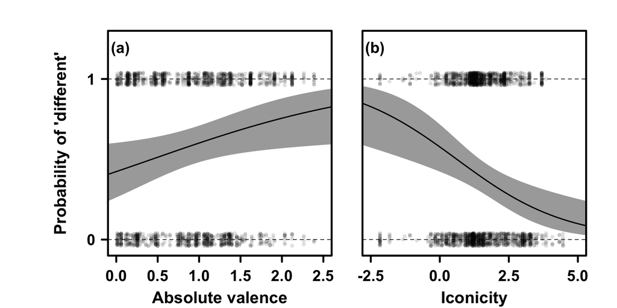

```r
## Make a plot of the exclusivity distributions:

set.seed(42)
quartz('', 11, 4)
par(mfrow = c(1,2),
    mai = c(0.25, 0.25, 0.25, 0.25),
    omi = c(0.6, 1.5, 0.25, 0.25))

# Plot 1:
plot(1, 1, type = 'n', xlim = c(0, 2.5),
     ylim = c(-0.1, 1.3),
     yaxs = 'i', xlab = '',
     ylab = '', xaxt = 'n', yaxt = 'n')
plot_AB(xlim = c(0, 2.5),
        ylim = c(-0.1, 1.3), AB = '(a)',
        xfactor = 0.02, yfactor = 0.08)
# Axes:
abline(h = c(0, 1), lty = 2)
points(COCA$AbsVal,
       jitter(as.numeric(COCA$Same) - 1, factor = 0.2),
       bg = rgb(0, 0, 0, 0.12), pch = 21, cex = 0.85, col = NA)
axis(side = 1, at = seq(0, 2.5, 0.5),
     lwd = 3, labels = FALSE)
axis(side = 1, at = seq(0, 2.5, 0.5),
     tick = FALSE, labels = TRUE,
     font = 2, line = 0.25, cex.axis = 1.5)
mtext(side = 1, line = 3.05, text = 'Absolute valence',
      cex = 1.6, font = 2)
axis(side = 2, at = seq(0, 5, 1),
     tick = TRUE, labels = TRUE,
     font = 2, cex.axis = 1.5, las = 2, lwd = 3)
mtext(side = 2, line = 3.2, text = "Probability of 'different'",
      cex = 1.6, font = 2)
# Plot data:
xseq <- c(absval_pred$AbsVal,
          rev(absval_pred$AbsVal))
yseq <- c(absval_pred$LB,
          rev(absval_pred$UB))
polygon(xseq, yseq,
        border = NA, col = rgb(0, 0, 0, 0.4))
with(absval_pred,
     points(AbsVal, Same, type = 'l', lwd = 2))
box(lwd = 3)

# Plot 2:
plot(1, 1, type = 'n', xlim = c(-2.5, 5),
     ylim = c(-0.1, 1.3), yaxs = 'i',
     xlab = '', ylab = '', xaxt = 'n', yaxt = 'n')
plot_AB(xlim = c(-2.5, 5),
        ylim = c(-0.1, 1.3), AB = '(b)',
        xfactor = 0.02, yfactor = 0.08)
# Axes:
abline(h = c(0, 1), lty = 2)
points(COCA$Iconicity,
       jitter(as.numeric(COCA$Same) - 1, factor = 0.2),
       bg = rgb(0, 0, 0, 0.12), pch = 21, cex = 0.85, col = NA)
axis(side = 1, at = seq(-2.5, 5, 2.5),
     lwd = 3, labels = F)
axis(side = 1, at = seq(-2.5, 5, 2.5),
     tick = FALSE, labels = TRUE,
     font = 2, line = 0.25, cex.axis = 1.5)
mtext(side = 1, line = 3.05, text = 'Iconicity',
      cex = 1.6, font = 2)
# Plot data:
xseq <- c(icon_pred$Iconicity,
          rev(icon_pred$Iconicity))
yseq <- c(icon_pred$LB,
          rev(icon_pred$UB))
polygon(xseq, yseq,
        border = NA, col = rgb(0, 0, 0, 0.4))
with(icon_pred,
     points(Iconicity, Same, type = 'l', lwd = 2))
box(lwd = 3)
```

## Check how much you can get done with the three-largest cells

This is reported throughout the chapter. How much can we get done with just the three largest cells?

```r
# Get the three biggest one each:

token3 <- rev(sort(as.vector(COCA_token_NA)))[1:3]
type3 <- rev(sort(as.vector(COCA_type_NA)))[1:3]
hapax3 <- rev(sort(as.vector(COCA_hapax_NA)))[1:3]

# How much percentage is this?

sum(token3) / sum(COCA_token_NA, na.rm = TRUE)
```

```
## [1] 0.6220444
```

```r
sum(type3) / sum(COCA_type_NA, na.rm = TRUE)
```

```
## [1] 0.6144201
```

```r
sum(hapax3) / sum(COCA_hapax_NA, na.rm = TRUE)
```

```
## [1] 0.6330532
```

```r
# How much percentage of the hierarchy-consistent is this?

sum(token3) / sum(COCA_token_NA[shen.matches])
```

```
## [1] 0.7235318
```

```r
sum(type3) / sum(COCA_type_NA[shen.matches])
```

```
## [1] 0.7293023
```

```r
sum(hapax3) / sum(COCA_hapax_NA[shen.matches])
```

```
## [1] 0.7483444
```

## Valence, iconicity and cosines

Repeat the analaysis with cosines. First, load the cosines in and then merge em with the predictor data.

```r
adj <- read_csv('../processed-data/combinations_with_cosines.csv')
adj <- left_join(adj, war,
                 by = c('Word' = 'Word'))
adj <- left_join(adj, snef,
                 by = c('Word' = 'Word'))
adj <- left_join(adj, icon,
                 by = c('Word' = 'Word'))
```

Next, we see whether each one of the predictors predicts cosines.

```r
## Valence:

summary(absval.cos <- lmer(Cosine ~ AbsVal +
                              (1|Word) +
                              (1 + AbsVal|Noun),
                            data = adj, REML = FALSE))
```

```
## Linear mixed model fit by maximum likelihood  ['lmerMod']
## Formula: Cosine ~ AbsVal + (1 | Word) + (1 + AbsVal | Noun)
##    Data: adj
##
##       AIC       BIC    logLik  deviance  df.resid
## -202421.5 -202354.7  101217.8 -202435.5    103193
##
## Scaled residuals:
##     Min      1Q  Median      3Q     Max
## -4.5276 -0.5734 -0.0155  0.4945 10.8137
##
## Random effects:
##  Groups   Name        Variance  Std.Dev. Corr
##  Noun     (Intercept) 0.0038657 0.06218
##           AbsVal      0.0006479 0.02545  -0.52
##  Word     (Intercept) 0.0188937 0.13745
##  Residual             0.0078880 0.08881
## Number of obs: 103200, groups:  Noun, 400; Word, 258
##
## Fixed effects:
##             Estimate Std. Error t value
## (Intercept)  0.81327    0.01603  50.739
## AbsVal      -0.02809    0.01452  -1.935
##
## Correlation of Fixed Effects:
##        (Intr)
## AbsVal -0.829
```

```r
absval.cos.null <- lmer(Cosine ~ 1 +
                              (1|Word) +
                              (1 + AbsVal|Noun),
                            data = adj, REML = FALSE)
anova(absval.cos.null,
      absval.cos, test = 'Chisq')
```

```
## Data: adj
## Models:
## absval.cos.null: Cosine ~ 1 + (1 | Word) + (1 + AbsVal | Noun)
## absval.cos: Cosine ~ AbsVal + (1 | Word) + (1 + AbsVal | Noun)
##                 Df     AIC     BIC logLik deviance  Chisq Chi Df
## absval.cos.null  6 -202420 -202363 101216  -202432
## absval.cos       7 -202422 -202355 101218  -202436 3.7184      1
##                 Pr(>Chisq)
## absval.cos.null
## absval.cos         0.05382 .
## ---
## Signif. codes:  0 '***' 0.001 '**' 0.01 '*' 0.05 '.' 0.1 ' ' 1
```

```r
save(absval.cos, file = '../models/absval.cos.mdl')

## Context valence:

summary(absval.context.cos <- lmer(Cosine ~ ContextAbsVal +
                              (1|Word) +
                              (1 + ContextAbsVal|Noun),
                            data = adj, REML = FALSE))
```

```
## Linear mixed model fit by maximum likelihood  ['lmerMod']
## Formula: Cosine ~ ContextAbsVal + (1 | Word) + (1 + ContextAbsVal | Noun)
##    Data: adj
##
##       AIC       BIC    logLik  deviance  df.resid
## -297822.2 -297752.2  148918.1 -297836.2    164793
##
## Scaled residuals:
##     Min      1Q  Median      3Q     Max
## -6.9173 -0.5989 -0.0214  0.5087 10.8303
##
## Random effects:
##  Groups   Name          Variance Std.Dev. Corr
##  Word     (Intercept)   0.018719 0.13682
##  Noun     (Intercept)   0.003093 0.05561
##           ContextAbsVal 0.001348 0.03672  -0.53
##  Residual               0.009280 0.09633
## Number of obs: 164800, groups:  Word, 412; Noun, 400
##
## Fixed effects:
##               Estimate Std. Error t value
## (Intercept)    0.82485    0.01110  74.285
## ContextAbsVal -0.08376    0.01318  -6.353
##
## Correlation of Fixed Effects:
##             (Intr)
## ContxtAbsVl -0.765
```

```r
absval.context.cos.null <- lmer(Cosine ~ 1 +
                              (1|Word) +
                              (1 + ContextAbsVal|Noun),
                            data = adj, REML = FALSE)
anova(absval.context.cos.null,
      absval.context.cos, test = 'Chisq')
```

```
## Data: adj
## Models:
## absval.context.cos.null: Cosine ~ 1 + (1 | Word) + (1 + ContextAbsVal | Noun)
## absval.context.cos: Cosine ~ ContextAbsVal + (1 | Word) + (1 + ContextAbsVal | Noun)
##                         Df     AIC     BIC logLik deviance  Chisq Chi Df
## absval.context.cos.null  6 -297786 -297726 148899  -297798
## absval.context.cos       7 -297822 -297752 148918  -297836 38.568      1
##                         Pr(>Chisq)
## absval.context.cos.null
## absval.context.cos       5.288e-10 ***
## ---
## Signif. codes:  0 '***' 0.001 '**' 0.01 '*' 0.05 '.' 0.1 ' ' 1
```

```r
save(absval.context.cos, file = '../models/absval.context.cos.mdl')

## Iconicity:

summary(iconicity.cos <- lmer(Cosine ~ Iconicity +
                              (1|Word) +
                              (1 + Iconicity|Noun),
                            data = adj, REML = FALSE))
```

```
## Linear mixed model fit by maximum likelihood  ['lmerMod']
## Formula: Cosine ~ Iconicity + (1 | Word) + (1 + Iconicity | Noun)
##    Data: adj
##
##       AIC       BIC    logLik  deviance  df.resid
## -303851.7 -303781.5  151932.9 -303865.7    168793
##
## Scaled residuals:
##     Min      1Q  Median      3Q     Max
## -5.3203 -0.6033 -0.0288  0.5301  9.7695
##
## Random effects:
##  Groups   Name        Variance  Std.Dev. Corr
##  Word     (Intercept) 0.0214729 0.14654
##  Noun     (Intercept) 0.0032695 0.05718
##           Iconicity   0.0002716 0.01648  -0.58
##  Residual             0.0093482 0.09669
## Number of obs: 168800, groups:  Word, 422; Noun, 400
##
## Fixed effects:
##             Estimate Std. Error t value
## (Intercept) 0.740831   0.011851  62.511
## Iconicity   0.016921   0.006401   2.644
##
## Correlation of Fixed Effects:
##           (Intr)
## Iconicity -0.773
```

```r
iconicity.cos.null <- lmer(Cosine ~ 1 +
                              (1|Word) +
                              (1 + Iconicity|Noun),
                            data = adj, REML = FALSE)
anova(iconicity.cos.null,
      iconicity.cos, test = 'Chisq')
```

```
## Data: adj
## Models:
## iconicity.cos.null: Cosine ~ 1 + (1 | Word) + (1 + Iconicity | Noun)
## iconicity.cos: Cosine ~ Iconicity + (1 | Word) + (1 + Iconicity | Noun)
##                    Df     AIC     BIC logLik deviance  Chisq Chi Df
## iconicity.cos.null  6 -303847 -303787 151929  -303859
## iconicity.cos       7 -303852 -303781 151933  -303866 6.9337      1
##                    Pr(>Chisq)
## iconicity.cos.null
## iconicity.cos        0.008459 **
## ---
## Signif. codes:  0 '***' 0.001 '**' 0.01 '*' 0.05 '.' 0.1 ' ' 1
```

```r
save(iconicity.cos, file = '../models/iconicity.cos.mdl')
```

Do the same thing with controls for gustatory/olfactory/auditory strength:

```r
## Valence:

summary(absval_gus.cos <- lmer(Cosine ~ AbsVal +
                                 AdjGustatoryStrengthMean +
                                 AdjOlfactoryStrengthMean +
                              (1|Word) +
                              (1 + AbsVal|Noun),
                            data = adj, REML = FALSE))
```

```
## Linear mixed model fit by maximum likelihood  ['lmerMod']
## Formula:
## Cosine ~ AbsVal + AdjGustatoryStrengthMean + AdjOlfactoryStrengthMean +
##     (1 | Word) + (1 + AbsVal | Noun)
##    Data: adj
##
##       AIC       BIC    logLik  deviance  df.resid
## -202535.9 -202450.0  101277.0 -202553.9    103191
##
## Scaled residuals:
##     Min      1Q  Median      3Q     Max
## -4.5292 -0.5731 -0.0154  0.4946 10.8131
##
## Random effects:
##  Groups   Name        Variance  Std.Dev. Corr
##  Noun     (Intercept) 0.0038653 0.06217
##           AbsVal      0.0006479 0.02545  -0.52
##  Word     (Intercept) 0.0119331 0.10924
##  Residual             0.0078880 0.08881
## Number of obs: 103200, groups:  Noun, 400; Word, 258
##
## Fixed effects:
##                           Estimate Std. Error t value
## (Intercept)               0.854788   0.013532  63.170
## AbsVal                    0.016967   0.012368   1.372
## AdjGustatoryStrengthMean -0.025243   0.006629  -3.808
## AdjOlfactoryStrengthMean -0.040237   0.007203  -5.586
##
## Correlation of Fixed Effects:
##             (Intr) AbsVal AdjGSM
## AbsVal      -0.692
## AdjGsttrySM -0.246  0.091
## AdjOlfctrSM  0.043 -0.307 -0.704
```

```r
absval_gus.cos.null <- lmer(Cosine ~ 1 +
                          AdjGustatoryStrengthMean +
                          AdjOlfactoryStrengthMean +
                              (1|Word) +
                              (1 + AbsVal|Noun),
                            data = adj, REML = FALSE)
anova(absval_gus.cos.null,
      absval_gus.cos, test = 'Chisq')
```

```
## Data: adj
## Models:
## absval_gus.cos.null: Cosine ~ 1 + AdjGustatoryStrengthMean + AdjOlfactoryStrengthMean +
## absval_gus.cos.null:     (1 | Word) + (1 + AbsVal | Noun)
## absval_gus.cos: Cosine ~ AbsVal + AdjGustatoryStrengthMean + AdjOlfactoryStrengthMean +
## absval_gus.cos:     (1 | Word) + (1 + AbsVal | Noun)
##                     Df     AIC     BIC logLik deviance  Chisq Chi Df
## absval_gus.cos.null  8 -202536 -202460 101276  -202552
## absval_gus.cos       9 -202536 -202450 101277  -202554 1.8753      1
##                     Pr(>Chisq)
## absval_gus.cos.null
## absval_gus.cos          0.1709
```

```r
save(absval_gus.cos, file = '../models/absval_gus.cos.mdl')

## Context valence:

summary(absval.context_gus.cos <- lmer(Cosine ~ ContextAbsVal +
                                         AdjGustatoryStrengthMean +
                                         AdjOlfactoryStrengthMean +
                              (1|Word) +
                              (1 + ContextAbsVal|Noun),
                            data = adj, REML = FALSE))
```

```
## Linear mixed model fit by maximum likelihood  ['lmerMod']
## Formula:
## Cosine ~ ContextAbsVal + AdjGustatoryStrengthMean + AdjOlfactoryStrengthMean +
##     (1 | Word) + (1 + ContextAbsVal | Noun)
##    Data: adj
##
##       AIC       BIC    logLik  deviance  df.resid
## -297963.0 -297872.9  148990.5 -297981.0    164791
##
## Scaled residuals:
##     Min      1Q  Median      3Q     Max
## -6.9187 -0.5991 -0.0212  0.5087 10.8304
##
## Random effects:
##  Groups   Name          Variance Std.Dev. Corr
##  Word     (Intercept)   0.013166 0.11474
##  Noun     (Intercept)   0.003092 0.05561
##           ContextAbsVal 0.001348 0.03672  -0.53
##  Residual               0.009280 0.09633
## Number of obs: 164800, groups:  Word, 412; Noun, 400
##
## Fixed effects:
##                           Estimate Std. Error t value
## (Intercept)               0.864771   0.009927  87.110
## ContextAbsVal            -0.041383   0.011565  -3.578
## AdjGustatoryStrengthMean -0.020371   0.005905  -3.450
## AdjOlfactoryStrengthMean -0.035780   0.006310  -5.670
##
## Correlation of Fixed Effects:
##             (Intr) CntxAV AdjGSM
## ContxtAbsVl -0.610
## AdjGsttrySM -0.134 -0.051
## AdjOlfctrSM -0.081 -0.140 -0.758
```

```r
absval.context_gus.cos.null <- lmer(Cosine ~ 1 +
                                      AdjGustatoryStrengthMean +
                                      AdjOlfactoryStrengthMean +
                              (1|Word) +
                              (1 + ContextAbsVal|Noun),
                            data = adj, REML = FALSE)
anova(absval.context_gus.cos.null,
      absval.context_gus.cos, test = 'Chisq')
```

```
## Data: adj
## Models:
## absval.context_gus.cos.null: Cosine ~ 1 + AdjGustatoryStrengthMean + AdjOlfactoryStrengthMean +
## absval.context_gus.cos.null:     (1 | Word) + (1 + ContextAbsVal | Noun)
## absval.context_gus.cos: Cosine ~ ContextAbsVal + AdjGustatoryStrengthMean + AdjOlfactoryStrengthMean +
## absval.context_gus.cos:     (1 | Word) + (1 + ContextAbsVal | Noun)
##                             Df     AIC     BIC logLik deviance  Chisq
## absval.context_gus.cos.null  8 -297952 -297872 148984  -297968
## absval.context_gus.cos       9 -297963 -297873 148991  -297981 12.619
##                             Chi Df Pr(>Chisq)
## absval.context_gus.cos.null
## absval.context_gus.cos           1  0.0003819 ***
## ---
## Signif. codes:  0 '***' 0.001 '**' 0.01 '*' 0.05 '.' 0.1 ' ' 1
```

```r
save(absval.context_gus.cos, file = '../models/absval.context_gus.cos.mdl')

## Iconicity:

summary(iconicity_aud.cos <- lmer(Cosine ~ Iconicity +
                                AdjAuditoryStrengthMean +
                              (1|Word) +
                              (1 + Iconicity|Noun),
                            data = adj, REML = FALSE))
```

```
## Linear mixed model fit by maximum likelihood  ['lmerMod']
## Formula: Cosine ~ Iconicity + AdjAuditoryStrengthMean + (1 | Word) + (1 +
##     Iconicity | Noun)
##    Data: adj
##
##       AIC       BIC    logLik  deviance  df.resid
## -303850.5 -303770.2  151933.3 -303866.5    168792
##
## Scaled residuals:
##     Min      1Q  Median      3Q     Max
## -5.3203 -0.6033 -0.0288  0.5300  9.7694
##
## Random effects:
##  Groups   Name        Variance  Std.Dev. Corr
##  Word     (Intercept) 0.0214317 0.14640
##  Noun     (Intercept) 0.0032695 0.05718
##           Iconicity   0.0002716 0.01648  -0.58
##  Residual             0.0093482 0.09669
## Number of obs: 168800, groups:  Word, 422; Noun, 400
##
## Fixed effects:
##                          Estimate Std. Error t value
## (Intercept)              0.743971   0.012343  60.272
## Iconicity                0.019240   0.006893   2.791
## AdjAuditoryStrengthMean -0.004342   0.004822  -0.900
##
## Correlation of Fixed Effects:
##             (Intr) Icncty
## Iconicity   -0.582
## AdjAdtryStM -0.283 -0.374
```

```r
iconicity_aud.cos.null <- lmer(Cosine ~ 1 +
                                 AdjAuditoryStrengthMean +
                              (1|Word) +
                              (1 + Iconicity|Noun),
                            data = adj, REML = FALSE)
anova(iconicity_aud.cos.null,
      iconicity_aud.cos, test = 'Chisq')
```

```
## Data: adj
## Models:
## iconicity_aud.cos.null: Cosine ~ 1 + AdjAuditoryStrengthMean + (1 | Word) + (1 + Iconicity |
## iconicity_aud.cos.null:     Noun)
## iconicity_aud.cos: Cosine ~ Iconicity + AdjAuditoryStrengthMean + (1 | Word) + (1 +
## iconicity_aud.cos:     Iconicity | Noun)
##                        Df     AIC     BIC logLik deviance  Chisq Chi Df
## iconicity_aud.cos.null  7 -303845 -303775 151929  -303859
## iconicity_aud.cos       8 -303851 -303770 151933  -303867 7.7206      1
##                        Pr(>Chisq)
## iconicity_aud.cos.null
## iconicity_aud.cos        0.005459 **
## ---
## Signif. codes:  0 '***' 0.001 '**' 0.01 '*' 0.05 '.' 0.1 ' ' 1
```

```r
save(iconicity_aud.cos, file = '../models/iconicity_aud.cos.mdl')
```

Finally, a subset-analysis of iconicity on auditory words only:

```r
## Iconicity:

sound_only <- filter(adj, DominantModality.x == 'Auditory')
summary(iconicity_aud_subset.cos <- lmer(Cosine ~ Iconicity +
                              (1|Word) +
                              (1 + Iconicity|Noun),
                            data = sound_only, REML = FALSE))
```

```
## Linear mixed model fit by maximum likelihood  ['lmerMod']
## Formula: Cosine ~ Iconicity + (1 | Word) + (1 + Iconicity | Noun)
##    Data: sound_only
##
##      AIC      BIC   logLik deviance df.resid
## -97810.1 -97752.6  48912.0 -97824.1    27193
##
## Scaled residuals:
##     Min      1Q  Median      3Q     Max
## -8.4004 -0.5076 -0.0220  0.5232  8.4638
##
## Random effects:
##  Groups   Name        Variance  Std.Dev. Corr
##  Noun     (Intercept) 1.780e-02 0.133411
##           Iconicity   5.327e-06 0.002308 -1.00
##  Word     (Intercept) 7.381e-03 0.085915
##  Residual             1.428e-03 0.037794
## Number of obs: 27200, groups:  Noun, 400; Word, 68
##
## Fixed effects:
##             Estimate Std. Error t value
## (Intercept) 0.654361   0.021973  29.780
## Iconicity   0.015640   0.008049   1.943
##
## Correlation of Fixed Effects:
##           (Intr)
## Iconicity -0.831
```

```r
iconicity_aud_subset.cos.null <- lmer(Cosine ~ 1 +
                              (1|Word) +
                              (1 + Iconicity|Noun),
                            data = sound_only, REML = FALSE)
anova(iconicity_aud_subset.cos.null,
      iconicity_aud_subset.cos, test = 'Chisq')
```

```
## Data: sound_only
## Models:
## iconicity_aud_subset.cos.null: Cosine ~ 1 + (1 | Word) + (1 + Iconicity | Noun)
## iconicity_aud_subset.cos: Cosine ~ Iconicity + (1 | Word) + (1 + Iconicity | Noun)
##                               Df    AIC    BIC logLik deviance Chisq
## iconicity_aud_subset.cos.null  6 -97808 -97759  48910   -97820
## iconicity_aud_subset.cos       7 -97810 -97753  48912   -97824 3.674
##                               Chi Df Pr(>Chisq)
## iconicity_aud_subset.cos.null
## iconicity_aud_subset.cos           1    0.05527 .
## ---
## Signif. codes:  0 '***' 0.001 '**' 0.01 '*' 0.05 '.' 0.1 ' ' 1
```

```r
save(iconicity_aud_subset.cos, file = '../models/iconicity_aud_subset.cos.mdl')
```

Check this with averages:

```r
COCA_avg <- adj %>%
  group_by(Word) %>%
  summarize(Cosine = mean(Cosine),
            AbsVal = mean(AbsVal),
            ContextAbsVal = mean(ContextAbsVal),
            Iconicity = mean(Iconicity),
            GustatoryStrengthMean = mean(AdjGustatoryStrengthMean),
            OlfactoryStrengthMean = mean(AdjOlfactoryStrengthMean),
            AuditoryStrengthMean = mean(AdjAuditoryStrengthMean))

# Analyses of averaged data:

summary(lm(Cosine ~ Iconicity + AbsVal, data = COCA_avg))
```

```
##
## Call:
## lm(formula = Cosine ~ Iconicity + AbsVal, data = COCA_avg)
##
## Residuals:
##      Min       1Q   Median       3Q      Max
## -0.49627 -0.03786  0.04549  0.08626  0.19725
##
## Coefficients:
##              Estimate Std. Error t value Pr(>|t|)
## (Intercept)  0.772276   0.019844  38.917  < 2e-16 ***
## Iconicity    0.028459   0.008452   3.367 0.000877 ***
## AbsVal      -0.028054   0.014286  -1.964 0.050652 .
## ---
## Signif. codes:  0 '***' 0.001 '**' 0.01 '*' 0.05 '.' 0.1 ' ' 1
##
## Residual standard error: 0.1356 on 254 degrees of freedom
##   (166 observations deleted due to missingness)
## Multiple R-squared:  0.05679,    Adjusted R-squared:  0.04936
## F-statistic: 7.646 on 2 and 254 DF,  p-value: 0.0005961
```

```r
summary(lm(Cosine ~ Iconicity + ContextAbsVal, data = COCA_avg))
```

```
##
## Call:
## lm(formula = Cosine ~ Iconicity + ContextAbsVal, data = COCA_avg)
##
## Residuals:
##      Min       1Q   Median       3Q      Max
## -0.49941 -0.06012  0.04077  0.09181  0.24063
##
## Coefficients:
##                Estimate Std. Error t value Pr(>|t|)
## (Intercept)    0.803128   0.013888  57.829  < 2e-16 ***
## Iconicity      0.014808   0.005966   2.482   0.0135 *
## ContextAbsVal -0.082823   0.013031  -6.356 5.55e-10 ***
## ---
## Signif. codes:  0 '***' 0.001 '**' 0.01 '*' 0.05 '.' 0.1 ' ' 1
##
## Residual standard error: 0.1365 on 408 degrees of freedom
##   (12 observations deleted due to missingness)
## Multiple R-squared:  0.1045, Adjusted R-squared:  0.1001
## F-statistic: 23.81 on 2 and 408 DF,  p-value: 1.658e-10
```

```r
# Analyses of averages:

summary(lm(Cosine ~ Iconicity + AbsVal +
             GustatoryStrengthMean +
             OlfactoryStrengthMean +
             AuditoryStrengthMean,
           data = COCA_avg))
```

```
##
## Call:
## lm(formula = Cosine ~ Iconicity + AbsVal + GustatoryStrengthMean +
##     OlfactoryStrengthMean + AuditoryStrengthMean, data = COCA_avg)
##
## Residuals:
##      Min       1Q   Median       3Q      Max
## -0.35221 -0.05295  0.01978  0.07117  0.21459
##
## Coefficients:
##                        Estimate Std. Error t value Pr(>|t|)
## (Intercept)            0.835628   0.017597  47.487  < 2e-16 ***
## Iconicity              0.021619   0.006949   3.111  0.00208 **
## AbsVal                 0.015152   0.012242   1.238  0.21698
## GustatoryStrengthMean -0.028474   0.006635  -4.292 2.53e-05 ***
## OlfactoryStrengthMean -0.037093   0.007330  -5.061 8.09e-07 ***
## AuditoryStrengthMean  -0.008407   0.005646  -1.489  0.13770
## ---
## Signif. codes:  0 '***' 0.001 '**' 0.01 '*' 0.05 '.' 0.1 ' ' 1
##
## Residual standard error: 0.1083 on 251 degrees of freedom
##   (166 observations deleted due to missingness)
## Multiple R-squared:  0.4051, Adjusted R-squared:  0.3932
## F-statistic: 34.18 on 5 and 251 DF,  p-value: < 2.2e-16
```

```r
summary(lm(Cosine ~ Iconicity + ContextAbsVal +
             GustatoryStrengthMean +
             OlfactoryStrengthMean +
             AuditoryStrengthMean, data = COCA_avg))
```

```
##
## Call:
## lm(formula = Cosine ~ Iconicity + ContextAbsVal + GustatoryStrengthMean +
##     OlfactoryStrengthMean + AuditoryStrengthMean, data = COCA_avg)
##
## Residuals:
##      Min       1Q   Median       3Q      Max
## -0.36356 -0.05603  0.00923  0.07370  0.29459
##
## Coefficients:
##                        Estimate Std. Error t value Pr(>|t|)
## (Intercept)            0.902044   0.013076  68.985  < 2e-16 ***
## Iconicity              0.009939   0.005226   1.902 0.057915 .
## ContextAbsVal         -0.041881   0.010885  -3.847 0.000139 ***
## GustatoryStrengthMean -0.025222   0.005668  -4.450 1.11e-05 ***
## OlfactoryStrengthMean -0.039979   0.006144  -6.507 2.26e-10 ***
## AuditoryStrengthMean  -0.026416   0.003801  -6.949 1.47e-11 ***
## ---
## Signif. codes:  0 '***' 0.001 '**' 0.01 '*' 0.05 '.' 0.1 ' ' 1
##
## Residual standard error: 0.1094 on 405 degrees of freedom
##   (12 observations deleted due to missingness)
## Multiple R-squared:  0.4294, Adjusted R-squared:  0.4224
## F-statistic: 60.96 on 5 and 405 DF,  p-value: < 2.2e-16
```

```r
## Check range:

range(adj$ContextAbsVal, na.rm = TRUE)
```

```
## [1] 0.0005058902 2.4156808883
```

```r
range(adj$Iconicity, na.rm = TRUE)
```

```
## [1] -2.166667  4.461538
```

```r
## Define predictors:

ContextAbsVal <- seq(-1, 3, 0.01)
Iconicity <- seq(-3, 6, 0.01)
```

Extract the predictions from the model:

```r
absval.context.cos_pred <- predict.glmm(fit = absval.context.cos,
             newdata = tibble(ContextAbsVal),
             type = 'gaussian')
iconicity.cos_pred <- predict.glmm(fit = iconicity.cos,
             newdata = tibble(Iconicity),
             type = 'gaussian')
```

Make a double-plot of this.

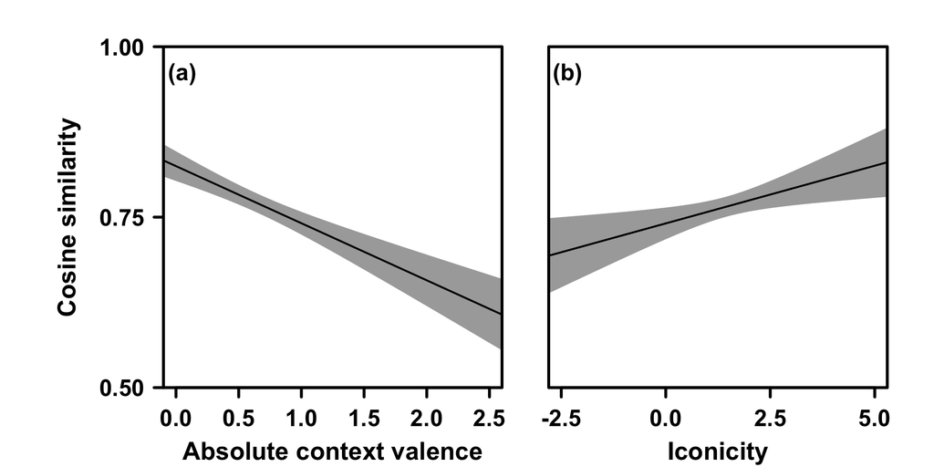

```r
## Make a plot of the exclusivity distributions:

set.seed(42)
quartz('', 11, 4)
par(mfrow = c(1,2),
    mai = c(0.25, 0.25, 0.25, 0.25),
    omi = c(0.6, 1.5, 0.25, 0.25))

# Plot 1:
plot(1, 1, type = 'n', xlim = c(0, 2.5),
     ylim = c(0.5, 1.0),
     yaxs = 'i', xlab = '',
     ylab = '', xaxt = 'n', yaxt = 'n')
plot_AB(xlim = c(0, 2.5),
        ylim = c(0.5, 1.0), AB = '(a)',
        xfactor = 0.02, yfactor = 0.08)
# Axes:
abline(h = c(0, 1), lty = 2)
axis(side = 1, at = seq(0, 2.5, 0.5),
     lwd = 3, labels = FALSE)
axis(side = 1, at = seq(0, 2.5, 0.5),
     tick = FALSE, labels = TRUE,
     font = 2, line = 0.25, cex.axis = 1.5)
mtext(side = 1, line = 3.05, text = 'Absolute context valence',
      cex = 1.6, font = 2)
axis(side = 2, at = seq(0.5, 1, 0.25),
     tick = TRUE, labels = TRUE,
     font = 2, cex.axis = 1.5, las = 2, lwd = 3)
mtext(side = 2, line = 4.5, text = "Cosine similarity",
      cex = 1.6, font = 2)
# Plot data:
xseq <- c(absval.context.cos_pred$ContextAbsVal,
          rev(absval.context.cos_pred$ContextAbsVal))
yseq <- c(absval.context.cos_pred$LB,
          rev(absval.context.cos_pred$UB))
polygon(xseq, yseq,
        border = NA, col = rgb(0, 0, 0, 0.4))
with(absval.context.cos_pred,
     points(ContextAbsVal, Cosine, type = 'l', lwd = 2))
box(lwd = 3)

# Plot 2:
plot(1, 1, type = 'n', xlim = c(-2.5, 5),
     ylim = c(0.5, 1.0), yaxs = 'i',
     xlab = '', ylab = '', xaxt = 'n', yaxt = 'n')
plot_AB(xlim = c(-2.5, 5),
        ylim = c(0.5, 1.0), AB = '(b)',
        xfactor = 0.02, yfactor = 0.08)
# Axes:
abline(h = c(0, 1), lty = 2)
axis(side = 1, at = seq(-2.5, 5, 2.5),
     lwd = 3, labels = F)
axis(side = 1, at = seq(-2.5, 5, 2.5),
     tick = FALSE, labels = TRUE,
     font = 2, line = 0.25, cex.axis = 1.5)
mtext(side = 1, line = 3.05, text = 'Iconicity',
      cex = 1.6, font = 2)
# Plot data:
xseq <- c(iconicity.cos_pred$Iconicity,
          rev(iconicity.cos_pred$Iconicity))
yseq <- c(iconicity.cos_pred$LB,
          rev(iconicity.cos_pred$UB))
polygon(xseq, yseq,
        border = NA, col = rgb(0, 0, 0, 0.4))
with(iconicity.cos_pred,
     points(Iconicity, Cosine, type = 'l', lwd = 2))
box(lwd = 3)
```

This completes the analyses presented in Chapter 17.